# MSqRob Vignette

Ludger Goeminne, Kris Gevaert and Lieven Clement

2018-11-23

## A first notice

This vignette might be a bit overwhelming for a first-time user.

**You might want to skim through this vignette and then take a look at the same two examples stripped to their essential analyses. These can be found at https://github.com/statOmics/MSqRobData/blob/master/inst/extdata/Francisella/analysis_Francisella.Rmd and https://github.com/statOmics/MSqRobData/blob/master/inst/extdata/CPTAC/analysis_CPTAC.Rmd for the *Francisella* and CPTAC example respectively.**

Note that we mainly focus on MaxQuant output, but that any type type of search engine output can be used with MSqRob, see “1.2. Importing other data types” for more info.

If anything is unclear, please do not hesitate to contact me at ludger.goeminne@vib-ugent.be or to open an issue on GitHub. Your feedback is highly welcomed!

## Introduction

This vignette will guide you through the main features of the MSqRob package. We will highlight two examples in order to help you familiarize with its main features.

The MSqRob package is designed for the analysis of differential abundance in label-free mass spectrometry-based shotgun proteomics experiments. These experiments typically output large spectral files (e.g. “.mzML” files) that need to be searched for identifications by specialized peak detection and peptide identification software such as Andromeda (used in the MaxQuant software package) and Mascot Distiller. These algorithms output lists of putative peptides accompanied by their corresponding overall intensity estimates.

Often, researchers further summarize these peptide intensities to protein intensities. However, as we have shown before, this summarization-based approaches tend to perform suboptimal compared to peptide-based models, wherein the peptide intensities are directly provided as input to the statistical model used for differential quantification (Goeminne et al., 2015). Nonetheless, most of these models still suffer from overfitting issues.

This package implements the robust ridge approach that prevents overfitting in sparse data but also accurately fits highly abundant proteins as described in Goeminne et al. (2016).

MSqRob is completely free and open source, but please make a reference to Goeminne et al. (2016) when using our package in any kind of publication.

## Downloading, installing and loading MSqRob

## Installing the package

On Windows, make sure that RTools is installed. Go to: https://cran.r-project.org/bin/windows/Rtools/ to download RTools. A user guide on how to install RTools on Windows can be found at: https://github.com/stan-dev/rstan/wiki/Install-Rtools-for-Windows. Errors in MSqRob on Windows related to unable to zip the results Excel file might be related to errors in configuring RTools.

First, we need to install the package devtools:

```r
#Change to eval=TRUE to execute this piece of code.
install.packages("devtools", repos = "http://cran.us.r-project.org")
library(devtools)
```

Then, we call this to install MSqRob from GitHub:

```r
#Change to eval=TRUE to execute this piece of code.
devtools::install_github("statOmics/MSqRob")
library(MSqRob)
```

Note that the latest version of MSqRob can always be found at: https://github.com/statOmics/MSqRob.

The latest version of this vignette can be found at: https://github.com/statOmics/MSqRob/blob/master/vignettes/MSqRob.Rmd.

## Loading MSqRob

Loading the package is done via the `library` command, as with any other package.

```r
library(MSqRob)
```

Additionally, we load the packages `Biobase`, `MSnbase` and `limma`, as we will use a few of their functions in this vignette.

```r
library(Biobase)
library(MSnbase)
library(limma)
```

## The MSqRobData package

R packages uploaded on CRAN have a maximum size limit of 5 MB. As proteomics datasets are typically several hunderds of GB in size and even an output file of a peptide search can be tens of MBs in size, we uploaded our example data in a separate data package called MSqRobData. If you want to run the examples in this vignette, you also need the data package. This can also be downloaded from GitHub in the following way:

```r
#Change to eval=TRUE to execute this piece of code.
devtools::install_github("statOmics/MSqRobData")
library(MSqRobData)
```

## The Shiny App

If you want to work with the Shiny graphical user interface (MaxQuant output only), use the following command:

```r
#Change to eval=TRUE to execute this piece of code.
shiny::runApp(system.file('App-MSqRob', package='MSqRob'))
```

## *Francisella tularensis* dataset (design with pseudoreplication)

The bacterium *Francisella tularensis* is a facultative intracellular parasite of macrophages and must import host cell arginine in order to be able to multiply inside the host cell. Ramond et al. (2015) investigated the effect of gene deletion of a newly identified arginine transporter called ArgP. Their data is deposited in the PRIDE repository at http://www.ebi.ac.uk/pride/archive/projects/PXD001584. We used the authors’ supplied peptides.txt file which is the result of preprocessing with MaxQuant version 1.4.1.2. As the authors used now outdated GI numbers, we modified this file to incorporate NCBI accessions and protein names (September 25, 2016).

### 1. Importing data

MSqRob data input can come from any kind of source, as long as feature-level or peptide-level data is available. I will here focus on a MaxQuant example, but in fact, output from any search engine can be used.

### 1.1. Importing MaxQuant data

First, specify the location of the peptides.txt MaxQuant output file. By default, MaxQuant creates a “combined” folder in the same folder as the raw files are (or if the raw files are in different directories, in the directory of the first raw file). The peptides.txt file can then be found in “path_to_raw_files/combined/txt/peptides.txt”. Just provide the path to where the file is located on your computer. The `system.file` function is used here only to access the example tab-delimited peptides.txt file that is delivered with our package.

```r
file_peptides_txt <- system.file("extdata/Francisella", "peptides.txt", package = "MSqRobData")
file_peptides_txt
```

```
## [1] "/Library/Frameworks/R.framework/Versions/3.5/Resources/library/MSqRobData/extdata/Francisella/peptides.txt"
```

Import the data using the `import2MSnSet` function. The `pattern` argument should contain a text string that is present in all column names that contain peptide intensities but not in the other column names. This defaults to `"Intensity\ "` for MaxQuant data. The default setting `remove_pattern=TRUE` then removes the pattern from these column names so that the names equal the names that were entered in MaxQuant’s “Experiment” column when conducting the search. In this particular *Francisella* experiment, our column names start with a number (either “1” or “3”), which is not a valid column name in R. Therefore, an “X” is prepended to these names.

```r
peptidesFranc <- import2MSnSet(file_peptides_txt, filetype = "MaxQuant", remove_pattern = TRUE)
```

`import2MSnSet` creates an `MSnSet` object with 3 slots:

- `exprs`: contains a matrix of peptide intensities of which the rows correspond to the peptides present in the dataset and the columns correspond to the different mass spec runs.
- `fData`: contains a data frame containing all additional information (such as peptide sequences, protein names, scores, number of missed cleavages, etc.) present in the input file.
- `pData`: contains a data frame with 0 columns and as many rows as there are mass spec runs. This slot will be used to store the experimental annotation.

If you want to assess whether importing happened in a correct way, you can always check the `exprs`, `fData` and `pData` slots.

The `exprs` slot should contain all the peptide intensities grouped per column.

```r
head(exprs(peptidesFranc))
```

```
##   X1WT_20_2h_n3_1 X1WT_20_2h_n3_2 X1WT_20_2h_n3_3 X1WT_20_2h_n4_1
## 1               0               0         9290400        92996000
## 2               0        20679000               0               0
## 3        28853000        28091000        30436000        19476000
## 4       339830000       420390000       393930000       235060000
## 5       240280000               0       241890000       222250000
## 6               0        31069000        31448000               0
##   X1WT_20_2h_n4_2 X1WT_20_2h_n4_3 X1WT_20_2h_n5_1 X1WT_20_2h_n5_2
## 1               0        98059000               0        80803000
## 2               0               0               0        17358000
## 3        22050000        20687000        36588000        28654000
## 4       381090000       360270000       255710000       311370000
## 5       189930000               0       160440000       147230000
## 6        27721000        28657000               0               0
##   X1WT_20_2h_n5_3 X3D8_20_2h_n3_1 X3D8_20_2h_n3_2 X3D8_20_2h_n3_3
```

[output cut: 20 more lines]

The `fData` slot contains all other columns.

```r
head(fData(peptidesFranc))
```

```
##                  Sequence Amino.acid.before First.amino.acid
## 1               AAAEELDTR                 K                A
## 2           AAAGFVITASHNK                 R                A
## 3 AAANEYELALAYSIEEVAPDLHK                 K                A
## 4            AAANNPQLEAFK                 K                A
## 5             AAASAGLVDEK                 K                A
## 6            AAASLDLYSYPK                 K                A
##   Second.amino.acid Second.last.amino.acid Last.amino.acid
## 1                 A                      T               R
## 2                 A                      N               K
## 3                 A                      H               K
## 4                 A                      F               K
## 5                 A                      E               K
## 6                 A                      P               K
##   Amino.acid.after A.Count R.Count N.Count D.Count C.Count Q.Count E.Count
```

[output cut: 132 more lines]

The `pData` slot will contain the experimental annotation. Right now, it has 18 rows (equal to the number of mass spec runs) and 0 columns (as the experimental annotation is not yet loaded).

```r
pData(peptidesFranc)
```

```
## data frame with 0 columns and 18 rows
```

### 1.2. Importing other data types

The `import2MSnSet` has built-in support for moFF (Argentini et al., 2016), mzTab (Griss et al., 2014) and Progenesis (Nonlinear Dynamics, Newcastle upon Tyne, U.K.) output. You should then simply set `filetype` to `"moFF"`, `"mzTab"` or `"Progenesis"` respectively.

If you are using yet another data type, you can use MSqRob’s `read2MSnSet` function to import your data. Hereby, you have to specify (1) your file, (2) a regular expression pattern that indicates the columns with the peptide intensities or simply the indices of these columns and (3) the separator (e.g. `"\t"`, `","`, …).

### 2. Preprocessing

### 2.1. Create an experimental annotation data frame.

Now, we are going to create a data frame that contains the experimental annotation. This data frame should contain all explanatory variables that groups different runs together. This is important in order to be able to include factors on which you will do inference (such as treatment effects or effects over time, or, in our case: the effect of the genetic knock-out) as well as other factors that might have an influence (such as biological repeats, technical repeats and potential confounders such as batch effects).

**Note that the “experimental annotation” can also be given as an Excel file or a tab delimited file!** This file should have the column names as a header (i.e. the first row in the file) and the same structure as the `exp_annotation` data frame we create below. If you have your experimental annotation in a file, just provide the filepath to this annotation file in the `preprocess_MaxQuant` function.

Also note that exactly one column in the experimental annotation should contain the names of the mass spec runs. These names should be equal to the names you entered in the “Experiment” column in MaxQuant (i.e. the column names of the `exprs` slot of the peptidesFranc `MSnSet` object). In our case, we will call this column “run” (see below). By default, MSqRob guesses this column by taking the only column of which its elements correspond to the column names of the `exprs` slot. If there is no such a column, or there are multiple such columns, MSqRob throws an error.

In this example, we create the experimental annotation data frame ourselves.

Extract the names of the mass spec runs. The mass spec run names are equal to the column names of the `exprs` slot of the peptidesFranc `MSnSet` object. Other columns in the experimental annotation data frame will typically be derived from this column.

```r
runs <- sampleNames(peptidesFranc)
runs
```

```
##  [1] "X1WT_20_2h_n3_1" "X1WT_20_2h_n3_2" "X1WT_20_2h_n3_3"
##  [4] "X1WT_20_2h_n4_1" "X1WT_20_2h_n4_2" "X1WT_20_2h_n4_3"
##  [7] "X1WT_20_2h_n5_1" "X1WT_20_2h_n5_2" "X1WT_20_2h_n5_3"
## [10] "X3D8_20_2h_n3_1" "X3D8_20_2h_n3_2" "X3D8_20_2h_n3_3"
## [13] "X3D8_20_2h_n4_1" "X3D8_20_2h_n4_2" "X3D8_20_2h_n4_3"
## [16] "X3D8_20_2h_n5_1" "X3D8_20_2h_n5_2" "X3D8_20_2h_n5_3"
```

```r
colnames(exprs(peptidesFranc))
```

```
##  [1] "X1WT_20_2h_n3_1" "X1WT_20_2h_n3_2" "X1WT_20_2h_n3_3"
##  [4] "X1WT_20_2h_n4_1" "X1WT_20_2h_n4_2" "X1WT_20_2h_n4_3"
##  [7] "X1WT_20_2h_n5_1" "X1WT_20_2h_n5_2" "X1WT_20_2h_n5_3"
## [10] "X3D8_20_2h_n3_1" "X3D8_20_2h_n3_2" "X3D8_20_2h_n3_3"
## [13] "X3D8_20_2h_n4_1" "X3D8_20_2h_n4_2" "X3D8_20_2h_n4_3"
## [16] "X3D8_20_2h_n5_1" "X3D8_20_2h_n5_2" "X3D8_20_2h_n5_3"
```

Note again that the sample names have a prepended “X” because a syntactically valid name in R cannot start with a number.

Add a factor for the genetic knock-out, which we will call “genotype” (i.e. wild type (WT) or knock-out (KO)).

```r
#Create the "genotype" vector
genotype <- factor(c(rep("WT",9),rep("KO",9)), levels=c("WT","KO"))
genotype
```

```
##  [1] WT WT WT WT WT WT WT WT WT KO KO KO KO KO KO KO KO KO
## Levels: WT KO
```

Add a factor for each of the 6 biological replicates (i.e. 3 biological repeats for each genotype).

```r
#Create a factor for the biological replicates
n <- nchar(runs)
biorep <- as.factor(paste0("b_",rep(1:6,each=3)))
biorep
```

```
##  [1] b_1 b_1 b_1 b_2 b_2 b_2 b_3 b_3 b_3 b_4 b_4 b_4 b_5 b_5 b_5 b_6 b_6
## [18] b_6
## Levels: b_1 b_2 b_3 b_4 b_5 b_6
```

```r
#Alternative: extract the biological repeat based on the mass spec run names.
# biorep <- as.factor(paste0("b_",factor(as.numeric(factor(paste0(substr(runs, 1,1),substr(runs, n-2,n-2))))+c(rep(0,9),rep(3,9)))))
```

Each of the 18 technical repeats are here represented by the 18 mass spec runs.

Create an experimental annotation data frame.

```r
exp_annotation <- data.frame(run=runs, genotype=genotype, biorep=biorep)
exp_annotation
```

```
##                run genotype biorep
## 1  X1WT_20_2h_n3_1       WT    b_1
## 2  X1WT_20_2h_n3_2       WT    b_1
## 3  X1WT_20_2h_n3_3       WT    b_1
## 4  X1WT_20_2h_n4_1       WT    b_2
## 5  X1WT_20_2h_n4_2       WT    b_2
## 6  X1WT_20_2h_n4_3       WT    b_2
## 7  X1WT_20_2h_n5_1       WT    b_3
## 8  X1WT_20_2h_n5_2       WT    b_3
## 9  X1WT_20_2h_n5_3       WT    b_3
## 10 X3D8_20_2h_n3_1       KO    b_4
## 11 X3D8_20_2h_n3_2       KO    b_4
## 12 X3D8_20_2h_n3_3       KO    b_4
## 13 X3D8_20_2h_n4_1       KO    b_5
## 14 X3D8_20_2h_n4_2       KO    b_5
## 15 X3D8_20_2h_n4_3       KO    b_5
## 16 X3D8_20_2h_n5_1       KO    b_6
## 17 X3D8_20_2h_n5_2       KO    b_6
## 18 X3D8_20_2h_n5_3       KO    b_6
```

Note that you can also import the experimental annotation from a tab-delimited or Excel file. As an example, we show you here how you can import data from an experimental annotation file delivered with our package. First, provide the path to where the data is saved.

```r
file_exp_annotation <- system.file("extdata/Francisella", "label-free_Francisella_annotation.xlsx", package = "MSqRobData")
file_exp_annotation
```

```
## [1] "/Library/Frameworks/R.framework/Versions/3.5/Resources/library/MSqRobData/extdata/Francisella/label-free_Francisella_annotation.xlsx"
```

Then, import the data using the `read.xlsx` function from the `openxlsx` package and convert the columns of the data frame to factors.

```r
#Import Excel file
exp_annotation_xlsx <- openxlsx::read.xlsx(file_exp_annotation)
#Convert columns of data frame to factors
exp_annotation_xlsx <- as.data.frame(unclass(exp_annotation_xlsx))
exp_annotation_xlsx
```

```
##               run genotype biorep
## 1  1WT_20_2h_n3_1       WT    b_1
## 2  1WT_20_2h_n3_2       WT    b_1
## 3  1WT_20_2h_n3_3       WT    b_1
## 4  1WT_20_2h_n4_1       WT    b_2
## 5  1WT_20_2h_n4_2       WT    b_2
## 6  1WT_20_2h_n4_3       WT    b_2
## 7  1WT_20_2h_n5_1       WT    b_3
## 8  1WT_20_2h_n5_2       WT    b_3
## 9  1WT_20_2h_n5_3       WT    b_3
## 10 3D8_20_2h_n3_1       KO    b_4
## 11 3D8_20_2h_n3_2       KO    b_4
## 12 3D8_20_2h_n3_3       KO    b_4
## 13 3D8_20_2h_n4_1       KO    b_5
## 14 3D8_20_2h_n4_2       KO    b_5
## 15 3D8_20_2h_n4_3       KO    b_5
## 16 3D8_20_2h_n5_1       KO    b_6
## 17 3D8_20_2h_n5_2       KO    b_6
## 18 3D8_20_2h_n5_3       KO    b_6
```

Note that here, there is no “X” prepended to the run names. However, names will be changed automatically to syntactically valid names by MSqRob during preprocessing.

### 2.2. Preprocess the data using the preprocess_MaxQuant function.

The identification of peptides that carry one or more chemical modifications is often not as reliable as the identification of unmodified peptides. Therefore, a common step during the preprocessing of proteomics data consists of removing the proteins of which all identified peptides have one or more modification sites. If we want to remove these proteins that are only identified by modified peptides from the dataset, we also need the proteinGroups.txt file. This file can be found in the same location as the peptides.txt file (“path_to_raw_files/combined/txt/proteinGroups.txt”). Here, we make use of the proteinGroups.txt file that is delivered with the package.

**Note:** if you don’t want to remove proteins that are only identified by modified peptides, set the `remove_only_site` argument of the `preprocess_MaxQuant` function to `FALSE` and leave the `file_proteinGroups` argument at its default value `NULL`.

Define the path to the proteinGroups.txt file.

```r
file_proteinGroups <- system.file("extdata/Francisella", "proteinGroups.txt", package = "MSqRobData")
file_proteinGroups
```

```
## [1] "/Library/Frameworks/R.framework/Versions/3.5/Resources/library/MSqRobData/extdata/Francisella/proteinGroups.txt"
```

Add to the `useful_properties` argument all column names of the `fData` slot of the peptidesFranc `MSnSet` object that you would like to keep (such as gene names, protein names, ontologies, etc.). Other columns will be removed for improved efficiency and memory usage. Here, we would like to keep the GI number and the protein names. These 2 columns are present in our peptides.txt file, but note that you can use basic R manipulations to add other columns to the fData slot if you want to. We certainly want to keep the “Sequence” slot, as peptide-specific effects must be included in our model.

```r
peptidesFranc2 <- preprocess_MaxQuant(peptidesFranc, accession="Proteins", exp_annotation=exp_annotation, logtransform=TRUE, base=2, normalisation="quantiles", smallestUniqueGroups=TRUE, useful_properties=c("GI number","Protein.names","Sequence"), filter=c("Contaminant","Reverse"), remove_only_site=TRUE, file_proteinGroups=file_proteinGroups,  filter_symbol="+", minIdentified=2)
```

We can now make density plots to inspect the effect of the preprocessing on the distribution of our log2-transformed peptide intensities.

### 3. Make diagnostic plots

Here we take a closer look at how you can make the diagnostic plots from the Shiny app. We will plot both the density plots and the MDS plot.

```r
#Make sure the order of the rows in your exp_annotation is the same as the columns of the exprs slot in your peptides object.
all(exp_annotation[,"run"]==colnames(exprs(peptidesFranc)))
```

```
## [1] TRUE
```

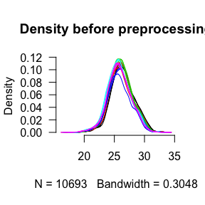

```r
#Color by biological repeat
colors <- as.numeric(exp_annotation[,"biorep"])

### Density plot before preprocessing ###

densAll <- apply(log2(exprs(peptidesFranc)),2,density,na.rm=TRUE)

#Automatically determine the plot window size
ymax=max(vapply(densAll,function(d) max(d$y),1))
rangematrix <- vapply(densAll,function(d) range(d$x, na.rm=TRUE), c(1,1)) #no longer
xlim=range(rangematrix,na.rm=TRUE)
ylim=c(0,ymax)

plot(densAll[[1]],col=colors[1],xlim=xlim,ylim=ylim, las=1, frame.plot=FALSE, main="Density before preprocessing")
for (i in 2:length(densAll)) lines(densAll[[i]],col=colors[i])
```

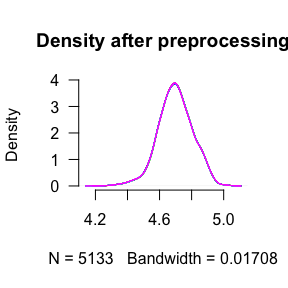

```r
######

### Density plot after preprocessing ###

densAll <- apply(log2(exprs(peptidesFranc2)),2,density,na.rm=TRUE)

#Automatically determine the plot window size
ymax=max(vapply(densAll,function(d) max(d$y),1))
rangematrix <- vapply(densAll,function(d) range(d$x, na.rm=TRUE), c(1,1)) #no longer
xlim=range(rangematrix,na.rm=TRUE)
ylim=c(0,ymax)

plot(densAll[[1]],col=colors[1],xlim=xlim,ylim=ylim, las=1, frame.plot=FALSE, main="Density after preprocessing")
for (i in 2:length(densAll)) lines(densAll[[i]],col=colors[i])
```

```r
######
```

We can also construct an MDS plot. This plot will cluster similar runs together.

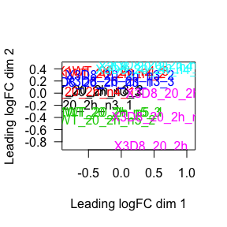

```r
plotMDS(exprs(peptidesFranc2), col=colors, las=1)
```

### 4. Convert the MSnSet object peptidesFranc2 into a protdata object proteinsFranc.

The `accession` argument denotes by which column the individual peptide observations should be grouped. The `annotations` argument indicates which columns in peptidesFranc2 are annotations linked to the accessions (in our case: the GI number and the protein names). These annotations will be added to a separate `annotation` slot.

```r
proteinsFranc <- MSnSet2protdata(peptidesFranc2, accession="Proteins", annotations = c("GI.number", "Protein.names"))
```

### Advanced: add information on the design after creating your protdata object

Imagine you forgot a factor in your experimental annotation. Should you redo the whole preprocessing part? No, often, you can still add this factor thanks to the `addVarFromVar` function. We will now show how we can add an extra (redundant) factor called `techrep`.

Create a factor for each of the 18 technical replicates (each sample was analyzed in triplicate). This factor is completely redundant, as the “run” column in the experimental annotation already has 18 different levels and is thus already equal to the factor for the technical replicates.

```r
techrep <- as.factor(paste0("t_",1:18))
names(techrep) <- levels(exp_annotation$run)
techrep
```

```
## X1WT_20_2h_n3_1 X1WT_20_2h_n3_2 X1WT_20_2h_n3_3 X1WT_20_2h_n4_1
##             t_1             t_2             t_3             t_4
## X1WT_20_2h_n4_2 X1WT_20_2h_n4_3 X1WT_20_2h_n5_1 X1WT_20_2h_n5_2
##             t_5             t_6             t_7             t_8
## X1WT_20_2h_n5_3 X3D8_20_2h_n3_1 X3D8_20_2h_n3_2 X3D8_20_2h_n3_3
##             t_9            t_10            t_11            t_12
## X3D8_20_2h_n4_1 X3D8_20_2h_n4_2 X3D8_20_2h_n4_3 X3D8_20_2h_n5_1
##            t_13            t_14            t_15            t_16
## X3D8_20_2h_n5_2 X3D8_20_2h_n5_3
##            t_17            t_18
## 18 Levels: t_1 t_10 t_11 t_12 t_13 t_14 t_15 t_16 t_17 t_18 t_2 ... t_9
```

```r
proteinsFranc2 <- addVarFromVar(proteinsFranc, basecol="run", name="techrep", vector=techrep)
proteinsFranc2
```

```
## @accession
##
## [1] "WP_003038655"
##
##  @annotation
##
##                                       GI.number
##                                  "gi|118497196"
##                                   Protein.names
## "hypothetical protein [Francisella tularensis]"
##
##  @data
##
##     quant_value           Sequence             run genotype biorep techrep
## 1.1    25.11978       AVVVFFDYGCGK X1WT_20_2h_n3_1       WT    b_1     t_1
## 1.2    25.34586 DLLSDPATPTVGPQDANK X1WT_20_2h_n3_1       WT    b_1     t_1
## 1.3    24.11491   ETNGELTVQDVDNVVK X1WT_20_2h_n3_1       WT    b_1     t_1
## 1.4    26.50674          IIAIPDIVK X1WT_20_2h_n3_1       WT    b_1     t_1
## 1.5    24.69046     QTNVITDNYQQAAK X1WT_20_2h_n3_1       WT    b_1     t_1
## 2.1    24.75196       AVVVFFDYGCGK X1WT_20_2h_n3_2       WT    b_1     t_2
##
##  96 more rows...
##
## @accession
##
## [1] "WP_003041237"
##
##  @annotation
##
##                                            GI.number
##                                       "gi|118498194"
##                                        Protein.names
## "phosphoglucosamine mutase [Francisella tularensis]"
##
##  @data
##
##     quant_value         Sequence             run genotype biorep techrep
## 1.1    25.81732    ADLGISLDGDADR X1WT_20_2h_n3_1       WT    b_1     t_1
## 1.2    27.36716        FVIVGQDTR X1WT_20_2h_n3_1       WT    b_1     t_1
## 1.3    24.91571  GEVANSTITAEFTQK X1WT_20_2h_n3_1       WT    b_1     t_1
```

[output cut: 98 more lines]

```
## 1.6    24.55598             VVFSVDYR X1WT_20_2h_n3_1       WT    b_1
## 2      24.53369         AAASLDLYSYPK X1WT_20_2h_n3_2       WT    b_1
## 2.1    24.68029              EVLFLNR X1WT_20_2h_n3_2       WT    b_1
## 2.2    23.16038 FPAGLNDVEFVAEHIFQHSK X1WT_20_2h_n3_2       WT    b_1
##     techrep
## 1.2     t_1
## 1.3     t_1
## 1.6     t_1
## 2       t_2
## 2.1     t_2
## 2.2     t_2
##
##  56 more rows...
##
## 1182 more elements...
```

### 5. Inspect the data for a specific protein via a detailed protein plot

Here, we illustrate how you can reproduce the detail plots from the Shiny app. We will take a closer look at the protein “WP_003039212”.

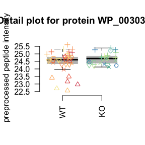

```r
protein_name <- "WP_003039212"
data <- getData(proteinsFranc[protein_name])

#We plot the peptide sequences as different point symbols
points <- as.numeric(droplevels(as.factor(data$Sequence)))
#We don't want to use repeated plot symbols or invisible symbols
pch_vals <- c(0:25,32:127)
#Repeat pch_vals if there would be more than 122 unique levels
pch_vals <- rep_len(pch_vals, length(unique(points)))
pch_vals <- pch_vals[points]

#We color by mass spec run
colors <- grDevices::colorRampPalette(RColorBrewer::brewer.pal(8,"Spectral"))(length(unique(droplevels(as.factor(data$run)))))
colors <- colors[as.numeric(droplevels(as.factor(data$run)))]

#We make a different boxplot for each genotype
boxplot(data$quant_value~as.factor(data$genotype), outline=FALSE, ylim=c(min(data$quant_value)-0.2,max(data$quant_value)+0.2), ylab="preprocessed peptide intensity", xlab="", main=paste0("Detail plot for protein ", protein_name), las=2, frame.plot=FALSE, frame=FALSE, col="grey", pars=list(boxcol="white"))

#Add the data as separate points
points(jitter((as.numeric(data$genotype)), factor=2),data$quant_value, col=colors, pch=pch_vals)
```

### 6. Fit the model

Fit the robust ridge models for each protein. The `fit.model` function will fit a model to each protein in the `protdata` object `proteinsFranc`. The default setting `reg="ridge"` indicates that ridge regression should be used. The default setting `weights="Huber"` indicates that an M estimation algorithm should be used that assigns Huber weights to each peptide observation based on their residuals.

Caution: fitting the models takes some time (less than 15 minutes for the *Francisella tularensis* dataset on our system).

```r
system.time(protLMFranc <- fit.model(proteinsFranc, response="quant_value", fixed=c("genotype"),  random=c("biorep","run","Sequence"), add.intercept=TRUE, weights="Huber"))
```

```
##    user  system elapsed
## 384.990   1.433 396.099
```

The `system.time` function was only added to output the duration of the model fitting. If you are not interested in this, you can of course omit it.

### 5.1. Inspect the model

`protLMFranc` is a `protLM` object.

```r
class(protLMFranc)
```

```
## [1] "protLM"
## attr(,"package")
## [1] "MSqRob"
```

Printing out a `protLM` object returns an overview of the first 6 accessions with their annotations and their corresponding models.

```r
protLMFranc
```

```
## @accession
##
## [1] "WP_003038655"
##
##  @annotation
##
##                                       GI.number
##                                  "gi|118497196"
##                                   Protein.names
## "hypothetical protein [Francisella tularensis]"
##
##  @model
##
## Linear mixed model fit by REML ['lmerMod']
## REML criterion at convergence: 66.4301
## Random effects:
##  Groups       Name        Std.Dev.
##  run          (Intercept) 0.0000
##  Sequence     (Intercept) 0.6682
##  biorep       (Intercept) 0.2247
##  ridgeGroup.1 (Intercept) 1.0983
##  Residual                 0.2524
## Number of obs: 102, groups:
## run, 18; Sequence, 7; biorep, 6; ridgeGroup.1, 1
## Fixed Effects:
## Intercept_MSqRob
##             -260
## fit warnings:
## Some predictor variables are on very different scales: consider rescaling
##
## @accession
##
## [1] "WP_003041237"
##
##  @annotation
##
##                                            GI.number
##                                       "gi|118498194"
##                                        Protein.names
## "phosphoglucosamine mutase [Francisella tularensis]"
```

[output cut: 126 more lines]

```
##  Groups       Name        Std.Dev.
##  run          (Intercept) 0.0000
##  Sequence     (Intercept) 0.6635
##  biorep       (Intercept) 0.0000
##  ridgeGroup.1 (Intercept) 0.3159
##  Residual                 0.2026
## Number of obs: 62, groups:
## run, 18; Sequence, 7; biorep, 6; ridgeGroup.1, 1
## Fixed Effects:
## Intercept_MSqRob
##           -192.6
## fit warnings:
## Some predictor variables are on very different scales: consider rescaling
##
## 1182 more elements...
```

The numbers in the `Std.Dev.` column give the estimated standard deviations of the random effects. Effects starting with `ridgeGroup` indicate shrunken fixed effects (we make use of the random effects framework of the `lm4` package in order to estimate Ridge penalties). However, as the fixed effects in the ridgeGroups are orthogonalized using the Gramm-Schmidt procedure, these numbers are not very informative.

A `protLM` object has three slots:

1. an `accession` slot: a vector containing all the accessions
2. a `model` slot: a list of all fitted models (one for each accession)
3. an `annotation` slot: data frame of which each row (one for each accession) corresponds to the annotations of a different accession.

These slots can be accessed using the `getAccessions`, `getModels` and `getAnnotations` functions respectively. Here we give the accessions, models and annotations for the first 5 models.

```r
getAccessions(protLMFranc)[1:5]
```

```
## [1] WP_003038655 WP_003041237 WP_003038915 WP_003038264 WP_003035781
## 1188 Levels: WP_003013731 WP_003013860 WP_003013909 ... WP_011733734
```

```r
getModels(protLMFranc)[1:5]
```

```
## [[1]]
## Linear mixed model fit by REML ['lmerMod']
## REML criterion at convergence: 66.4301
## Random effects:
##  Groups       Name        Std.Dev.
##  run          (Intercept) 0.0000
##  Sequence     (Intercept) 0.6682
##  biorep       (Intercept) 0.2247
##  ridgeGroup.1 (Intercept) 1.0983
##  Residual                 0.2524
## Number of obs: 102, groups:
## run, 18; Sequence, 7; biorep, 6; ridgeGroup.1, 1
## Fixed Effects:
## Intercept_MSqRob
##             -260
## fit warnings:
## Some predictor variables are on very different scales: consider rescaling
##
## [[2]]
## Linear mixed model fit by REML ['lmerMod']
## REML criterion at convergence: 136.4625
## Random effects:
##  Groups       Name        Std.Dev.
##  run          (Intercept) 0.00000
##  Sequence     (Intercept) 1.28720
##  biorep       (Intercept) 0.09322
##  ridgeGroup.1 (Intercept) 0.00000
##  Residual                 0.27463
## Number of obs: 193, groups:
## run, 18; Sequence, 12; biorep, 6; ridgeGroup.1, 1
## Fixed Effects:
## Intercept_MSqRob
##           -370.9
## fit warnings:
## Some predictor variables are on very different scales: consider rescaling
##
## [[3]]
## Linear mixed model fit by REML ['lmerMod']
## REML criterion at convergence: 340.3599
## Random effects:
```

[output cut: 34 more lines]

```
## REML criterion at convergence: 57.1314
## Random effects:
##  Groups       Name        Std.Dev.
##  run          (Intercept) 0.0000
##  biorep       (Intercept) 0.2059
##  Sequence     (Intercept) 1.9048
##  ridgeGroup.1 (Intercept) 0.5694
##  Residual                 0.3522
## Number of obs: 47, groups:
## run, 18; biorep, 6; Sequence, 3; ridgeGroup.1, 1
## Fixed Effects:
## Intercept_MSqRob
##           -173.3
## fit warnings:
## Some predictor variables are on very different scales: consider rescaling
```

```r
getAnnotations(protLMFranc)[1:5,]
```

```
##      GI.number
## [1,] "gi|118497196"
## [2,] "gi|118498194"
## [3,] "gi|118497331"
## [4,] "gi|118496879"
## [5,] "gi|118497152"
##      Protein.names
## [1,] "hypothetical protein [Francisella tularensis]"
## [2,] "phosphoglucosamine mutase [Francisella tularensis]"
## [3,] "glycine--tRNA ligase subunit beta [Francisella tularensis]"
## [4,] "molecular chaperone HtpG [Francisella tularensis]"
## [5,] "delta-aminolevulinic acid dehydratase [Francisella tularensis]"
```

`protLM` objects can be subsetted using either their numeric index or their corresponding accession.

Retain only the part corresponding to model 24 and model 50.

```r
protLMFranc[c(24,50)]
```

```
## @accession
##
## [1] "WP_003035135"
##
##  @annotation
##
##                                       GI.number
##                                  "gi|118498204"
##                                   Protein.names
## "superoxide dismutase [Francisella tularensis]"
##
##  @model
##
## Linear mixed model fit by REML ['lmerMod']
## REML criterion at convergence: 130.6537
## Random effects:
##  Groups       Name        Std.Dev.
##  run          (Intercept) 0.00000
##  Sequence     (Intercept) 1.48360
##  biorep       (Intercept) 0.05107
##  ridgeGroup.1 (Intercept) 1.40062
##  Residual                 0.29509
## Number of obs: 148, groups:
## run, 18; Sequence, 10; biorep, 6; ridgeGroup.1, 1
## Fixed Effects:
## Intercept_MSqRob
##           -344.8
## fit warnings:
## Some predictor variables are on very different scales: consider rescaling
##
## @accession
##
## [1] "WP_003041024"
##
##  @annotation
##
##                                 GI.number
##                            "gi|118496740"
##                             Protein.names
## "acetate kinase [Francisella tularensis]"
##
##  @model
##
## Linear mixed model fit by REML ['lmerMod']
## REML criterion at convergence: 26.4739
## Random effects:
##  Groups       Name        Std.Dev.
##  run          (Intercept) 0.0000
##  biorep       (Intercept) 0.2982
##  Sequence     (Intercept) 0.3214
##  ridgeGroup.1 (Intercept) 0.0000
##  Residual                 0.2708
## Number of obs: 36, groups:
## run, 16; biorep, 6; Sequence, 4; ridgeGroup.1, 1
## Fixed Effects:
## Intercept_MSqRob
##           -147.4
## fit warnings:
## Some predictor variables are on very different scales: consider rescaling
```

Inspect the `protLM` object corresponding to accession `"WP_003033643"`.

```r
protLMFranc["WP_003033643"]
```

```
## @accession
##
## [1] "WP_003033643"
##
##  @annotation
##
##                                  GI.number
##                             "gi|118497379"
##                              Protein.names
## "isochorismatase [Francisella tularensis]"
##
##  @model
##
## Linear mixed model fit by REML ['lmerMod']
## REML criterion at convergence: 5.8471
## Random effects:
##  Groups       Name        Std.Dev.
##  run          (Intercept) 0.0000
##  biorep       (Intercept) 0.1829
##  Sequence     (Intercept) 1.1305
##  ridgeGroup.1 (Intercept) 0.3079
##  Residual                 0.9620
## Number of obs: 3, groups:  run, 3; biorep, 2; Sequence, 1; ridgeGroup.1, 1
## Fixed Effects:
## Intercept_MSqRob
##           -36.64
## fit warnings:
## Some predictor variables are on very different scales: consider rescaling
```

Say we want to inspect cell division protein `"WP_003040227"`. We can then select protein `"WP_003040227"` from the `protLM` object. We can extract the model via the `getModels` function. `simplify=TRUE` is the default setting and indicates that if you select one model, you only want this model and not a list with as only element this model. Note that if you select multiple models, you automatically receive a list of models.

```r
modelWP_003040227 <- getModels(protLMFranc["WP_003040227"], simplify=TRUE)
modelWP_003040227
```

```
## Linear mixed model fit by REML ['lmerMod']
## REML criterion at convergence: 35.3401
## Random effects:
##  Groups       Name        Std.Dev.
##  run          (Intercept) 0.0000
##  biorep       (Intercept) 0.5312
##  Sequence     (Intercept) 0.0000
##  ridgeGroup.1 (Intercept) 0.8636
##  Residual                 0.4931
## Number of obs: 20, groups:
## run, 15; biorep, 5; Sequence, 2; ridgeGroup.1, 1
## Fixed Effects:
## Intercept_MSqRob
##           -111.7
## fit warnings:
## Some predictor variables are on very different scales: consider rescaling
```

```r
betaBVcovDf <- getBetaVcovDf(modelWP_003040227)
```

```r
betaBVcovDf$beta
```

```
##                              [,1]
## (Intercept)          2.478692e+01
## runX1WT_20_2h_n4_1  -3.268340e-19
## runX1WT_20_2h_n4_2   6.312569e-19
## runX1WT_20_2h_n4_3  -5.514836e-19
## runX1WT_20_2h_n5_1  -2.653938e-19
## runX1WT_20_2h_n5_2   1.300820e-19
## runX1WT_20_2h_n5_3   3.002867e-20
## runX3D8_20_2h_n3_1   6.312569e-19
## runX3D8_20_2h_n3_2   5.345092e-20
## runX3D8_20_2h_n3_3  -7.547956e-20
## runX3D8_20_2h_n4_1   3.677317e-19
## runX3D8_20_2h_n4_2   1.418812e-19
## runX3D8_20_2h_n4_3  -3.821573e-19
## runX3D8_20_2h_n5_1  -3.498709e-19
## runX3D8_20_2h_n5_2  -1.035900e-19
## runX3D8_20_2h_n5_3   6.912076e-20
## biorepb_2           -2.866945e-01
## biorepb_3           -1.221728e-01
## biorepb_4            7.069615e-01
## biorepb_5            1.479023e-01
## biorepb_6           -4.459965e-01
## SequenceMVFTFYNNLK   6.400946e-19
## SequenceYTYIYQIASFR -6.400946e-19
## genotypeKO           2.573084e-01
```

```r
betaBVcovDf$vcov
```

```
##                       (Intercept) runX1WT_20_2h_n4_1 runX1WT_20_2h_n4_2
## (Intercept)          4.644336e-01      -1.133292e-19      -7.590798e-20
## runX1WT_20_2h_n4_1  -1.133292e-19       1.000000e-18       2.081844e-37
## runX1WT_20_2h_n4_2  -7.590798e-20       2.081844e-37       1.000000e-18
## runX1WT_20_2h_n4_3  -1.133292e-19       3.108154e-37       2.081844e-37
## runX1WT_20_2h_n5_1  -1.036390e-19       2.528956e-38       1.693897e-38
## runX1WT_20_2h_n5_2  -1.036390e-19       2.528956e-38       1.693897e-38
## runX1WT_20_2h_n5_3  -1.036390e-19       2.528956e-38       1.693897e-38
## runX3D8_20_2h_n3_1  -1.868609e-20       4.559704e-39       3.054093e-39
## runX3D8_20_2h_n3_2  -4.832685e-20       1.179252e-38       7.898639e-39
## runX3D8_20_2h_n3_3  -4.832685e-20       1.179252e-38       7.898639e-39
## runX3D8_20_2h_n4_1  -2.678135e-20       6.535074e-39       4.377198e-39
## runX3D8_20_2h_n4_2  -5.356270e-20       1.307015e-38       8.754397e-39
## runX3D8_20_2h_n4_3  -5.356270e-20       1.307015e-38       8.754397e-39
## runX3D8_20_2h_n5_1  -4.575672e-20       1.116537e-38       7.478572e-39
## runX3D8_20_2h_n5_2  -4.575672e-20       1.116537e-38       7.478572e-39
## runX3D8_20_2h_n5_3  -4.575672e-20       1.116537e-38       7.478572e-39
## biorepb_2           -3.511045e-01      -1.974862e-19      -1.322764e-19
## biorepb_3           -3.607947e-01       8.803963e-20       5.896902e-20
## biorepb_4           -1.338428e-01       3.265976e-20       2.187553e-20
## biorepb_5           -1.553883e-01       3.791720e-20       2.539697e-20
## biorepb_6           -1.592912e-01       3.886959e-20       2.603489e-20
## SequenceMVFTFYNNLK  -5.668853e-19      -1.056869e-37      -7.078916e-38
## SequenceYTYIYQIASFR -4.331147e-19       1.056869e-37       7.078916e-38
## genotypeKO          -2.822640e-01       6.887691e-20       4.613381e-20
##                     runX1WT_20_2h_n4_3 runX1WT_20_2h_n5_1
## (Intercept)              -1.133292e-19      -1.036390e-19
## runX1WT_20_2h_n4_1        3.108154e-37       2.528956e-38
## runX1WT_20_2h_n4_2        2.081844e-37       1.693897e-38
## runX1WT_20_2h_n4_3        1.000000e-18       2.528956e-38
## runX1WT_20_2h_n5_1        2.528956e-38       1.000000e-18
## runX1WT_20_2h_n5_2        2.528956e-38       2.820767e-37
## runX1WT_20_2h_n5_3        2.528956e-38       2.820767e-37
## runX3D8_20_2h_n3_1        4.559704e-39       4.169826e-39
## runX3D8_20_2h_n3_2        1.179252e-38       1.078420e-38
## runX3D8_20_2h_n3_3        1.179252e-38       1.078420e-38
## runX3D8_20_2h_n4_1        6.535074e-39       5.976293e-39
## runX3D8_20_2h_n4_2        1.307015e-38       1.195259e-38
## runX3D8_20_2h_n4_3        1.307015e-38       1.195259e-38
## runX3D8_20_2h_n5_1        1.116537e-38       1.021067e-38
```

[output cut: 195 more lines]

```
## runX3D8_20_2h_n3_3       -9.604086e-38        9.604086e-38 -4.661813e-20
## runX3D8_20_2h_n4_1       -3.944178e-37        3.944178e-37 -2.583443e-20
## runX3D8_20_2h_n4_2        2.111644e-37       -2.111644e-37 -5.166885e-20
## runX3D8_20_2h_n4_3        2.111644e-37       -2.111644e-37 -5.166885e-20
## runX3D8_20_2h_n5_1        3.465504e-38       -3.465504e-38 -4.413888e-20
## runX3D8_20_2h_n5_2        3.465504e-38       -3.465504e-38 -4.413888e-20
## runX3D8_20_2h_n5_3        3.465504e-38       -3.465504e-38 -4.413888e-20
## biorepb_2                -3.274279e-19        3.274279e-19  2.133871e-01
## biorepb_3                 4.403841e-19       -4.403841e-19  2.192765e-01
## biorepb_4                -2.659883e-19        2.659883e-19 -1.291104e-01
## biorepb_5                 3.238866e-20       -3.238866e-20 -1.498941e-01
## biorepb_6                 1.206434e-19       -1.206434e-19 -1.536591e-01
## SequenceMVFTFYNNLK        1.000000e-18        3.142651e-36 -7.108561e-20
## SequenceYTYIYQIASFR       3.142651e-36        1.000000e-18  7.108561e-20
## genotypeKO               -7.108561e-20        7.108561e-20  4.579926e-01
```

```r
betaBVcovDf$df
```

```
## [1] 18.69393
```

```r
betaBVcovDf$df_exp
```

```r
betaBVcovDf$sigma
```

[output not shown]

The `getBetaVcovDfList` function can be applied on (a subset of) the `protLM` object `protLMFranc`. This returns a list containing one or more lists similar to the `betaBVcovDf` list.

```r
betaVcovDfList <- getBetaVcovDfList(protLMFranc[1:2])
#Inspect the structure of the list without printing it out compeletely:
str(betaVcovDfList)
```

```
## List of 2
##  $ WP_003038655:List of 6
##   ..$ beta   : num [1:33, 1] 2.57e+01 -9.42e-20 1.96e-19 -5.17e-19 -1.58e-19 ...
##   .. ..- attr(*, "dimnames")=List of 2
##   .. .. ..$ : chr [1:33] "(Intercept)" "runX1WT_20_2h_n3_1" "runX1WT_20_2h_n3_2" "runX1WT_20_2h_n3_3" ...
##   .. .. ..$ : NULL
##   ..$ vcov   : num [1:33, 1:33] 1.23 -7.08e-20 -1.04e-19 -8.46e-20 -9.38e-20 ...
##   .. ..- attr(*, "dimnames")=List of 2
##   .. .. ..$ : chr [1:33] "(Intercept)" "runX1WT_20_2h_n3_1" "runX1WT_20_2h_n3_2" "runX1WT_20_2h_n3_3" ...
##   .. .. ..$ : chr [1:33] "(Intercept)" "runX1WT_20_2h_n3_1" "runX1WT_20_2h_n3_2" "runX1WT_20_2h_n3_3" ...
##   ..$ df     : num 93.4
##   ..$ sigma  : num 0.252
##   ..$ df_exp : NULL
##   ..$ df_pars: Named num [1:33] 1.00 3.19e-18 3.70e-18 3.48e-18 3.31e-18 ...
##   .. ..- attr(*, "names")= chr [1:33] "(Intercept)" "runX1WT_20_2h_n3_1" "runX1WT_20_2h_n3_2" "runX1WT_20_2h_n3_3" ...
##  $ WP_003041237:List of 6
##   ..$ beta   : num [1:38, 1] 2.67e+01 -6.09e-19 -2.51e-20 3.31e-19 -1.80e-18 ...
##   .. ..- attr(*, "dimnames")=List of 2
##   .. .. ..$ : chr [1:38] "(Intercept)" "runX1WT_20_2h_n3_1" "runX1WT_20_2h_n3_2" "runX1WT_20_2h_n3_3" ...
##   .. .. ..$ : NULL
##   ..$ vcov   : num [1:38, 1:38] 1.86 -5.44e-20 -6.04e-20 -5.10e-20 -3.68e-20 ...
##   .. ..- attr(*, "dimnames")=List of 2
##   .. .. ..$ : chr [1:38] "(Intercept)" "runX1WT_20_2h_n3_1" "runX1WT_20_2h_n3_2" "runX1WT_20_2h_n3_3" ...
##   .. .. ..$ : chr [1:38] "(Intercept)" "runX1WT_20_2h_n3_1" "runX1WT_20_2h_n3_2" "runX1WT_20_2h_n3_3" ...
##   ..$ df     : num 180
##   ..$ sigma  : num 0.274
##   ..$ df_exp : NULL
##   ..$ df_pars: Named num [1:38] 1.00 7.14e-18 7.28e-18 6.98e-18 5.14e-18 ...
##   .. ..- attr(*, "names")= chr [1:38] "(Intercept)" "runX1WT_20_2h_n3_1" "runX1WT_20_2h_n3_2" "runX1WT_20_2h_n3_3" ...
```

### 6.2 Save your results

You can save your `proteinsFranc` and `protLMFranc` objects to a .RDatas object that can be loaded in R or in the Shiny graphical user interface. If you want your .RDatas object to be loaded into the Shiny App, you should also specify the `levelOptions`, `random` and `plot2DependentVars` objects. These objects are settings that are saved automatically when using the MSqRob Shiny App. In this example, I save the .RDatas object to my desktop.

```r
#Change to eval=TRUE to execute this piece of code.

result_files_new <- list()
result_files_new$proteins <- proteinsFranc
result_files_new$models <- protLMFranc

### This part is only needed if you want to load your .RDatas file in the MSqRob Shiny App ###

#Should contain all contrast options for the fixed effects (see also 5. Statistical inference)
result_files_new$levelOptions <- c("genotypeWT","genotypeKO")
#Should contain all random effects
result_files_new$random <- c("Sequence","biorep","run")
#Should contain a list with all fixed and random effects
result_files_new$plot2DependentVars <- as.list(c("genotype","Sequence","biorep","run"))

#############################################################################################

saves_MSqRob(result_files, file="/Users/lgoeminn/Desktop/project_Francisella.RDatas") #Change file path to your desired save location!
```

If you want to load your saved file, first specify the folder where it is saved.

```r
#Change to eval=TRUE to execute this piece of code.
result_path <- "/Users/lgoeminn/Desktop/project_Francisella.RDatas"
```

To inspect the different objects in the file, you can use the `inspect_loads_MSqRob` function.

```r
#Change to eval=TRUE to execute this piece of code.
inspect_loads_MSqRob(result_path)
```

To load this file and assign new `protdata` and `protLM` object to it, execute the following piece of code.

```r
#Change to eval=TRUE to execute this piece of code.

#To load the "project_Francisella.RDatas" file
result_files <- loads_MSqRob(result_path)

#assign a new protdata object to the saved proteins
proteinsFranc_result <- result_files$proteins
#assign a new protLM object to the saved models
protLMFranc_result <- result_files$models
```

### 7. Statistical inference

We are interested in which proteins differ significantly in abundance between ArgP mutant and wild type *Francisella tularensis*. Via the `"MSqRob_levels"` attribute, you can check which factor levels are present in each model. Pick a model for which there are no missing levels for the factors for which you want to test contrasts and inspect the names. Note that these names are always the combination of the parameter name and the factor level.

```r
attr(modelWP_003040227,"MSqRob_levels")
```

```
##  [1] "(Intercept)"         "genotypeWT"          "genotypeKO"
##  [4] "runX1WT_20_2h_n4_1"  "runX1WT_20_2h_n4_2"  "runX1WT_20_2h_n4_3"
##  [7] "runX1WT_20_2h_n5_1"  "runX1WT_20_2h_n5_2"  "runX1WT_20_2h_n5_3"
## [10] "runX3D8_20_2h_n3_1"  "runX3D8_20_2h_n3_2"  "runX3D8_20_2h_n3_3"
## [13] "runX3D8_20_2h_n4_1"  "runX3D8_20_2h_n4_2"  "runX3D8_20_2h_n4_3"
## [16] "runX3D8_20_2h_n5_1"  "runX3D8_20_2h_n5_2"  "runX3D8_20_2h_n5_3"
## [19] "biorepb_2"           "biorepb_3"           "biorepb_4"
## [22] "biorepb_5"           "biorepb_6"           "SequenceMVFTFYNNLK"
## [25] "SequenceYTYIYQIASFR"
```

Here, we notice that the mutant is encoded as `"genotypeKO"` and the wild type as `"genotypeWT"`. We construct a contrast matrix `L` for inferring on the fold change of interest. We are interested in the log2 fold change between mutant and wild type. As all intensities are log2-transformed, we should take the difference between `"genotypeKO"` and `"genotypeWT"` (because of the following property of logarithms: log2(a/b)=log2(a)-log2(b)).

```r
L <- makeContrast(contrasts=c("genotypeKO-genotypeWT"),
                  levels=c("genotypeWT","genotypeKO"))
L
```

```
##             Contrasts
## Levels       genotypeKO-genotypeWT
##   genotypeWT                    -1
##   genotypeKO                     1
```

Imagine we would want to test the average log2 protein intensity between mutant and wild type, then `L` would be constructed as follows:

```r
L2 <- makeContrast(contrasts=c("genotypeKO/2+genotypeWT/2"),
                  levels=c("genotypeWT","genotypeKO"))
L2
```

```
##             Contrasts
## Levels       genotypeKO/2+genotypeWT/2
##   genotypeWT                       0.5
##   genotypeKO                       0.5
```

**Important notification:** do not use the estimated parameters beta to determine the factor levels! You will notice for example that the level `"genotypeWT"` is missing in the column names of the betas. This is because `"genotypeWT"` is the reference class, giving the parameter corresponding to `"genotypeKO"` the interpretation of the effect of `"genotypeKO"` relative to `"genotypeWT"`. It is important however to include `"genotypeWT"` in the contrast matrix because for proteins where factor levels are missing, these parameters can get different interpretations. The `makeContrast` function takes this into account and will return `NA` when a contrast cannot be properly estimated.

```r
betaBVcovDf$beta
```

```
##                              [,1]
## (Intercept)          2.478692e+01
## runX1WT_20_2h_n4_1  -3.268340e-19
## runX1WT_20_2h_n4_2   6.312569e-19
## runX1WT_20_2h_n4_3  -5.514836e-19
## runX1WT_20_2h_n5_1  -2.653938e-19
## runX1WT_20_2h_n5_2   1.300820e-19
## runX1WT_20_2h_n5_3   3.002867e-20
## runX3D8_20_2h_n3_1   6.312569e-19
## runX3D8_20_2h_n3_2   5.345092e-20
## runX3D8_20_2h_n3_3  -7.547956e-20
## runX3D8_20_2h_n4_1   3.677317e-19
## runX3D8_20_2h_n4_2   1.418812e-19
## runX3D8_20_2h_n4_3  -3.821573e-19
## runX3D8_20_2h_n5_1  -3.498709e-19
## runX3D8_20_2h_n5_2  -1.035900e-19
## runX3D8_20_2h_n5_3   6.912076e-20
## biorepb_2           -2.866945e-01
## biorepb_3           -1.221728e-01
## biorepb_4            7.069615e-01
## biorepb_5            1.479023e-01
## biorepb_6           -4.459965e-01
## SequenceMVFTFYNNLK   6.400946e-19
## SequenceYTYIYQIASFR -6.400946e-19
## genotypeKO           2.573084e-01
```

Build a data frame containing estimate, standard error, degrees of freedom, T-value and p-value for each protein in the `protLM` object protLMFranc, by using the `test.protLMcontrast` function.

```r
resultFranc <- test.protLMcontrast(protLMFranc, L)
```

The `prot.p.adjust` function adds a new column `"qval"` to the data frame based on an existing `"pval"` column. The new column contains adjusted p-values using one of the methods in the `p.adjust.methods` vector.

```r
resultFranc <- prot.p.adjust(resultFranc, method="fdr")
```

The `prot.signif` function needs a matrix (or a list of matrices) containing a column named “pval” and a column named `"qval"`. The `"pval"` column will be used to sort the matrix. The function generates a new column `"signif"` containing 1 for all values of `"qval"` with a value lower than the specified FDR level (default: 0.05) and 0 otherwise.

```r
resultFranc <- prot.signif(resultFranc, level = 0.05)
```

Inspect the first 6 significant proteins:

```r
head(resultFranc,6)
```

```
##                 GI.number
## WP_003040894 gi|118496676
## WP_003026016 gi|118497407
## WP_003023392 gi|118497654
## WP_003040849 gi|118496659
## WP_003020026 gi|118496882
## WP_003038350 gi|118496950
##                                                                                           Protein.names
## WP_003040894                       3-isopropylmalate dehydratase large subunit [Francisella tularensis]
## WP_003026016                                                   biotin synthase [Francisella tularensis]
## WP_003023392 tRNA (N6-isopentenyl adenosine(37)-C2)-methylthiotransferase MiaB [Francisella tularensis]
## WP_003040849                                              hypothetical protein [Francisella tularensis]
## WP_003020026                                                    CTP synthetase [Francisella tularensis]
## WP_003038350                                              hypothetical protein [Francisella tularensis]
##                estimate         se        df      Tval         pval
## WP_003040894 -0.9057261 0.05555518 121.14412 -16.30318 2.457599e-32
## WP_003026016 -0.9617749 0.07478739 133.04725 -12.86012 4.225036e-25
## WP_003023392 -1.3965407 0.08530562  44.43458 -16.37103 1.941754e-20
## WP_003040849 -1.1356799 0.09816434 101.51013 -11.56917 3.023500e-20
## WP_003020026 -0.5163597 0.04825840 150.49382 -10.69989 3.184831e-20
## WP_003038350  0.8107740 0.06684619  72.40727  12.12895 4.127913e-19
##                      qval signif
## WP_003040894 2.831154e-29   TRUE
## WP_003026016 2.433621e-22   TRUE
## WP_003023392 7.337851e-18   TRUE
## WP_003040849 7.337851e-18   TRUE
## WP_003020026 7.337851e-18   TRUE
## WP_003038350 7.925594e-17   TRUE
```

### Advanced: importing as a data frame

It is also possible to import your data as a simple data frame and make use of some custom preprocessing pipeline. Here, we will show the same preprocessing pipeline for the *Francisella* dataset as outlined above, but note that adding, removing or modifying steps in the preprocessing pipeline is now very simple as the data is in data frame format.

First, we import the *Francisella* dataset as a data frame via the base R function `read.table`.

```r
pepFrancDf <- read.table(file = file_peptides_txt, sep = "\t", header = TRUE, quote="", comment.char = "")
```

Of course, other filetypes can also be imported. Say for example your input file is a comma separated file stored in My Documents on a Windows computer, you could use for example:

```r
#Change to eval=TRUE to execute this piece of code.
pepFrancDf <- read.table("C:/Users/Ludger/Documents/peptides.csv", sep = ",", dec=".", header = TRUE, quote="", comment.char = "")
```

The data frame `pepFrancD` is in wide format.

```r
head(pepFrancDf)
```

```
##                  Sequence Amino.acid.before First.amino.acid
## 1               AAAEELDTR                 K                A
## 2           AAAGFVITASHNK                 R                A
## 3 AAANEYELALAYSIEEVAPDLHK                 K                A
## 4            AAANNPQLEAFK                 K                A
## 5             AAASAGLVDEK                 K                A
## 6            AAASLDLYSYPK                 K                A
##   Second.amino.acid Second.last.amino.acid Last.amino.acid
## 1                 A                      T               R
## 2                 A                      N               K
## 3                 A                      H               K
## 4                 A                      F               K
## 5                 A                      E               K
## 6                 A                      P               K
##   Amino.acid.after A.Count R.Count N.Count D.Count C.Count Q.Count E.Count
```

[output cut: 195 more lines]

If we want to mimick the MaxQuant preprocessing pipeline, we need to add a factor that indicates whether a protein is only identified by modified peptides. This requires some basic R programming. The information about which proteins are only identified by modified peptides can be found in the proteinGroups.txt file. We again make use of the proteinGroups.txt file that is delivered with the package.

```r
#Import the proteinGroups.txt file delivered with the MSqRobData package
file_proteinGroups <- system.file("extdata/Francisella", "proteinGroups.txt", package = "MSqRobData")

  proteinGroups <- read.table(file_proteinGroups, sep="\t", header=TRUE, quote="", comment.char = "")

  #Extract the column that indicates which proteins are only identified by a modification site
  only_site <- proteinGroups$Only.identified.by.site

  #If there are no such proteins (as is the case here), the column will be completely empty and R will import this by default as "NA". However, we want the an empty value instead of "NA" to keep this column consistent with the "Contaminant" and "Reverse" columns.
  only_site[is.na(only_site)] <- ""
  #Select the protein accessions that are only identified by one or more modified peptides
  filter_symbol <- "+"
  removed_proteins <- proteinGroups$Protein.IDs[only_site==filter_symbol]

  #Create a logical variable "rem" that holds "TRUE" if a row in the pepFrancDf data frame should be removed and FALSE otherwise.
  accession <- "Proteins"
  rem <- as.character(pepFrancDf[,accession]) %in% as.character(removed_proteins)

  #Create a new column "only_site" in "pepFrancDf" that indicates with a "+" which rows should be removed.
  pepFrancDf$only_site <- ""
  pepFrancDf$only_site[rem] <- "+"
```

Note that in this particular case, the previous chunck of code was superfluous, as there are no proteins in the dataset that are only identified by modified peptides.

We can easily preprocess the data frame using the `preprocess_wide` function (for data in “long” format, use the `preprocess_long` function). This function uses our standard preprocessing pipeline on data frames in “wide” format (i.e. the data frame has one observation row per subject with each measurement present as a different variable).

We already made the `exp_annotation` object before (see “2.1. Create an experimental annotation data frame.”), so we will not repeat this code again here. **Importantly, however, contrary to the `exprs` slot in the `peptidesFranc2` object created before, the names of all intensity columns in data frame `pepFrancDf` start with “Intensity.”.**

**This is because the default setting `remove_pattern=TRUE` in the `import2MSnSet` function removes the prefix `"Intensity\ "` from the columns containing the intensities as this allows users that are unfamiliar with R to just copy and paste the names they provided in MaxQuant’s “Experiment” column as an input. Here, we just imported the peptides.txt file as it is.** We thus create a new experimental annotation data frame called `exp_annotation2` with run names starting with “Intensity.” (a space is not syntactically valid in R, so it is automatically converted to a dot).

```r
runs2 <- colnames(pepFrancDf)[grepl("Intensity.",colnames(pepFrancDf))]
runs2
```

```
##  [1] "Intensity.1WT_20_2h_n3_1" "Intensity.1WT_20_2h_n3_2"
##  [3] "Intensity.1WT_20_2h_n3_3" "Intensity.1WT_20_2h_n4_1"
##  [5] "Intensity.1WT_20_2h_n4_2" "Intensity.1WT_20_2h_n4_3"
##  [7] "Intensity.1WT_20_2h_n5_1" "Intensity.1WT_20_2h_n5_2"
##  [9] "Intensity.1WT_20_2h_n5_3" "Intensity.3D8_20_2h_n3_1"
## [11] "Intensity.3D8_20_2h_n3_2" "Intensity.3D8_20_2h_n3_3"
## [13] "Intensity.3D8_20_2h_n4_1" "Intensity.3D8_20_2h_n4_2"
## [15] "Intensity.3D8_20_2h_n4_3" "Intensity.3D8_20_2h_n5_1"
## [17] "Intensity.3D8_20_2h_n5_2" "Intensity.3D8_20_2h_n5_3"
```

```r
#Extract the relevant part of the mass spec run names that points to the genotype.
genotype2 <- factor(substr(runs2, 11,13))
genotype2
```

```
##  [1] 1WT 1WT 1WT 1WT 1WT 1WT 1WT 1WT 1WT 3D8 3D8 3D8 3D8 3D8 3D8 3D8 3D8
## [18] 3D8
## Levels: 1WT 3D8
```

```r
n <- nchar(runs2)
biorep2 <- as.factor(paste0("b_",factor(as.numeric(factor(paste0(substr(runs2, 10,10),substr(runs2, n-2,n-2))))+c(rep(0,9),rep(3,9)))))
biorep
```

```
##  [1] b_1 b_1 b_1 b_2 b_2 b_2 b_3 b_3 b_3 b_4 b_4 b_4 b_5 b_5 b_5 b_6 b_6
## [18] b_6
## Levels: b_1 b_2 b_3 b_4 b_5 b_6
```

```r
exp_annotation2 <- data.frame(run=runs2, genotype=genotype2, biorep=biorep2)
exp_annotation2
```

```
##                         run genotype biorep
## 1  Intensity.1WT_20_2h_n3_1      1WT    b_1
## 2  Intensity.1WT_20_2h_n3_2      1WT    b_1
## 3  Intensity.1WT_20_2h_n3_3      1WT    b_1
## 4  Intensity.1WT_20_2h_n4_1      1WT    b_2
## 5  Intensity.1WT_20_2h_n4_2      1WT    b_2
## 6  Intensity.1WT_20_2h_n4_3      1WT    b_2
## 7  Intensity.1WT_20_2h_n5_1      1WT    b_3
## 8  Intensity.1WT_20_2h_n5_2      1WT    b_3
## 9  Intensity.1WT_20_2h_n5_3      1WT    b_3
## 10 Intensity.3D8_20_2h_n3_1      3D8    b_4
## 11 Intensity.3D8_20_2h_n3_2      3D8    b_4
## 12 Intensity.3D8_20_2h_n3_3      3D8    b_4
## 13 Intensity.3D8_20_2h_n4_1      3D8    b_5
## 14 Intensity.3D8_20_2h_n4_2      3D8    b_5
## 15 Intensity.3D8_20_2h_n4_3      3D8    b_5
## 16 Intensity.3D8_20_2h_n5_1      3D8    b_6
## 17 Intensity.3D8_20_2h_n5_2      3D8    b_6
## 18 Intensity.3D8_20_2h_n5_3      3D8    b_6
```

The `preprocess_wide` function allows for the same preprocessing as the `preprocess_MaxQuant` function on a regular data frame. If you inspect this function, you will notice that the same 8 preprocessing steps are executed. Remember that you can do any preprocessing you like using basic R data frame manipulations. The `split` argument indicates which character string is used to separate the accession groups. The `exp_annotation` argument, like before, contains the experimental annotation data frame or a character string indicating the filepath where the experimental annotation is saved as an Excel file or a tab-delimited file. The `quant_cols` argument contains a vector of names or a vector of numeric indices pointing to the columns containing the quantitative values of interest (mostly intensities or areas under the curve). If `quant_cols` contains only one character string, each column containing this pattern will be regarded as a column containing the quantitative values of interest. `aggr_by` indicates the column by which the data should be aggregated. Here, the data is already aggregated to the peptide level (i.e. over different charge states and modification statuses). We need no further aggregation, thus we provide the “Sequence” column (the level to which aggregation has already been done). `aggr_function` will be superfluous here, but if further aggregation would have been necessary, raw intensities would be summed up (`aggr_function="sum"`). The other parameters are similar to the `preprocess_MaxQuant` function.

```r
pepFrancDf2 <- preprocess_wide(pepFrancDf, accession="Proteins", split=";", exp_annotation=exp_annotation2, quant_cols="Intensity.", aggr_by="Sequence", aggr_function="sum", logtransform=TRUE, base=2, normalisation="quantiles", smallestUniqueGroups=TRUE, useful_properties=c("GI.number","Protein.names","Sequence"), filter=c("Contaminant","Reverse","only_site"), filter_symbol="+", minIdentified=2)
```

Note that the experimental annotation is now present as an attribute of the `pepFrancDf2` data frame.

```r
attr(pepFrancDf2,"MSqRob_exp_annotation")
```

```
##                         run genotype biorep
## 1  Intensity.1WT_20_2h_n3_1      1WT    b_1
## 2  Intensity.1WT_20_2h_n3_2      1WT    b_1
## 3  Intensity.1WT_20_2h_n3_3      1WT    b_1
## 4  Intensity.1WT_20_2h_n4_1      1WT    b_2
## 5  Intensity.1WT_20_2h_n4_2      1WT    b_2
## 6  Intensity.1WT_20_2h_n4_3      1WT    b_2
## 7  Intensity.1WT_20_2h_n5_1      1WT    b_3
## 8  Intensity.1WT_20_2h_n5_2      1WT    b_3
## 9  Intensity.1WT_20_2h_n5_3      1WT    b_3
## 10 Intensity.3D8_20_2h_n3_1      3D8    b_4
## 11 Intensity.3D8_20_2h_n3_2      3D8    b_4
## 12 Intensity.3D8_20_2h_n3_3      3D8    b_4
## 13 Intensity.3D8_20_2h_n4_1      3D8    b_5
## 14 Intensity.3D8_20_2h_n4_2      3D8    b_5
## 15 Intensity.3D8_20_2h_n4_3      3D8    b_5
## 16 Intensity.3D8_20_2h_n5_1      3D8    b_6
## 17 Intensity.3D8_20_2h_n5_2      3D8    b_6
## 18 Intensity.3D8_20_2h_n5_3      3D8    b_6
```

After custom preprocessing, you can transform the data to a `protdata` object via the `df2protdata` function.

The `acc_col` argument in the `df2protdata` function indicates the column index or column name of the accessions (i.e. the protein (group) identifiers). The `quant_cols` argument is a vector of indices pointing to all columns containing peptide intensities. In the example below, the column named “Proteins” will be added to the `accession` slot while all columns with indices in the `quant_cols` vector will be added as a matrix to the `intensities` slot. `quant_name` indicates the name that will be given to the column containing the (preprocessed) intensities and `run_name` indicates the name that will be given to the column containing the mass spec run names in the new `protdata` object. Like before, we keep “GI.number” and “Protein.names” as annotations.

```r
#Select columns with intensities.
quant_cols <- which(grepl("Intensity.", colnames(pepFrancDf2)))
quant_cols
```

```
##  [1]  5  6  7  8  9 10 11 12 13 14 15 16 17 18 19 20 21 22
```

```r
#Call df2protdata function
proteinsFrancDf <- df2protdata(pepFrancDf2, acc_col="Proteins", quant_cols=quant_cols, quant_name="quant_value", run_name="run", annotations=c("GI.number","Protein.names"))
#Inspect proteinsFrancDf protdata object.
proteinsFrancDf
```

```
## @accession
##
## [1] "WP_003038655"
##
##  @annotation
##
##                                       GI.number
##                                  "gi|118497196"
##                                   Protein.names
## "hypothetical protein [Francisella tularensis]"
##
##  @data
##
##   quant_value           Sequence genotype biorep                      run
## 2    25.11978       AVVVFFDYGCGK      1WT    b_1 Intensity.1WT_20_2h_n3_1
## 3    25.34586 DLLSDPATPTVGPQDANK      1WT    b_1 Intensity.1WT_20_2h_n3_1
## 4    24.11491   ETNGELTVQDVDNVVK      1WT    b_1 Intensity.1WT_20_2h_n3_1
## 5    26.50674          IIAIPDIVK      1WT    b_1 Intensity.1WT_20_2h_n3_1
## 6    24.69046     QTNVITDNYQQAAK      1WT    b_1 Intensity.1WT_20_2h_n3_1
## 9    24.75196       AVVVFFDYGCGK      1WT    b_1 Intensity.1WT_20_2h_n3_2
##
##  96 more rows...
##
## @accession
##
## [1] "WP_003041237"
##
##  @annotation
##
##                                            GI.number
##                                       "gi|118498194"
##                                        Protein.names
## "phosphoglucosamine mutase [Francisella tularensis]"
##
##  @data
##
##   quant_value         Sequence genotype biorep                      run
## 2    25.81732    ADLGISLDGDADR      1WT    b_1 Intensity.1WT_20_2h_n3_1
## 3    27.36716        FVIVGQDTR      1WT    b_1 Intensity.1WT_20_2h_n3_1
## 4    24.91571  GEVANSTITAEFTQK      1WT    b_1 Intensity.1WT_20_2h_n3_1
```

[output cut: 98 more lines]

```
## 7     24.55598             VVFSVDYR      1WT    b_1
## 8     24.53369         AAASLDLYSYPK      1WT    b_1
## 9     24.68029              EVLFLNR      1WT    b_1
## 10    23.16038 FPAGLNDVEFVAEHIFQHSK      1WT    b_1
##                         run
## 3  Intensity.1WT_20_2h_n3_1
## 4  Intensity.1WT_20_2h_n3_1
## 7  Intensity.1WT_20_2h_n3_1
## 8  Intensity.1WT_20_2h_n3_2
## 9  Intensity.1WT_20_2h_n3_2
## 10 Intensity.1WT_20_2h_n3_2
##
##  56 more rows...
##
## 1182 more elements...
```

## CPTAC dataset (randomized complete block design)

```r
library(MSqRob)
library(Biobase)
```

This example involves the CPTAC Study 6. In this dataset Sigma’s UPS1 standard containing 48 human proteins was spiked into a reference yeast proteome and analyzed on 7 instruments in 5 different laboratories (Paulovich et al., 2010). Raw data files can be downloaded at: https://cptac-data-portal.georgetown.edu/cptac/dataPublic/list?currentPath=%2FPhase_I_Data%2FStudy6&nonav=true

Here, we limited ourselves to the data of LTQ-Orbitrap at site 86, LTQ-Orbitrap O at site 65 and LTQ-Orbitrap W at site 56. The data was searched with MaxQuant version 1.5.2.8. Detailed search settings can be found in Goeminne et al. (2016).

### 1. Import MaxQuant’s peptides.txt file

First, specify the location of the peptides.txt MaxQuant output file. By default, MaxQuant creates a “combined” folder in the same folder as the raw files are (or if the raw files are in different directories, in the directory of the first raw file). The peptides.txt file can then be found in “path_to_raw_files/combined/txt/peptides.txt”. Here, we make use of the peptides.txt file that is delivered with the package.

```r
file_peptides_txt <- system.file("extdata/CPTAC", "peptides.txt", package = "MSqRobData")
```

Import MaxQuant’s peptides.txt file and convert it to an `MSnSet` object (see package `MSnbase`).

```r
peptidesCPTAC <- import2MSnSet(file_peptides_txt, filetype="MaxQuant", remove_pattern=TRUE)
```

The “pattern” argument indicates which columns in the peptides.txt file contain peptide intensities. Currently, all columns containing `"Intensity\ "` in their column names will be treated as peptide intensities (default for MaxQuant). `remove_pattern=TRUE` (default) indicates that the name of the pattern is removed from the column names.

### 2. Preprocessing

### 2.1. Add information on the design: create an experimental annotation data frame.

Extract the names of the mass spec runs via the `sampleNames` function from the `Biobase` package.

```r
runs <- sampleNames(peptidesCPTAC)
```

Note that as the names again start with a number, an “X” is prepended to make the names syntactically valid. Add a grouping factor for the spike-in condition (i.e. 6A, 6B, 6C, 6D and 6E).

```r
condition <- factor(substr(runs, 2,3))
```

Add a grouping factor for the lab effect (i.e. LTQ-Orbitrap at site 86, LTQ-Orbitrap O at site 65 and LTQ-Orbitrap W at site 56).

```r
lab <- factor(rep(rep(1:3,each=3),5))
#Alternative:
#lab <- factor((as.numeric(substr(runs, 5,5))-1)%/%3+1)
```

Create an experimental annotation data frame.

```r
exp_annotation <- data.frame(run=runs, condition=condition, lab=lab)
exp_annotation
```

```
##      run condition lab
## 1  X6A_1        6A   1
## 2  X6A_2        6A   1
## 3  X6A_3        6A   1
## 4  X6A_4        6A   2
## 5  X6A_5        6A   2
## 6  X6A_6        6A   2
## 7  X6A_7        6A   3
## 8  X6A_8        6A   3
## 9  X6A_9        6A   3
## 10 X6B_1        6B   1
## 11 X6B_2        6B   1
## 12 X6B_3        6B   1
## 13 X6B_4        6B   2
## 14 X6B_5        6B   2
```

[output cut: 31 more lines]

Remember that the `exp_annotation` can also be given as an Excel file or a tab delimited file!

### 2.2. Preprocess the data using the preprocess_MaxQuant function.

If we want to remove proteins that are only identified by modified peptides from the dataset, we also need the proteinGroups.txt file. This file can be found in the same location as the peptides.txt file (“path_to_raw_files/combined/txt/proteinGroups.txt”). Here, we make use of the proteinGroups.txt file that is delivered with the package.

Note: if you don’t want to remove proteins that are only identified by modified peptides, set `remove_only_site=FALSE` and leave the `file_proteinGroups` argument at its default value (`NULL`).

```r
file_proteinGroups <- system.file("extdata/CPTAC", "proteinGroups.txt", package = "MSqRobData")
```

**Important:** in the CPTAC dataset, some human UPS proteins are NOT contaminants as these proteins were spiked in on purpose! We only want to remove those contaminants that are not human UPS proteins. We thus need to unmark these proteins as contaminant before preprocessing.

```r
fData(peptidesCPTAC)[grepl("_HUMAN_UPS", fData(peptidesCPTAC)$Proteins),]$Potential.contaminant <- ""
```

Add to `useful_properties` all column names of the `fData` slot of the peptidesCPTAC `MSnSet` object that you would like to keep (such as gene names, protein names, ontologies, etc.). Other columns will be removed for improved efficiency and memory usage. We certainly want to keep the “Proteins” slot, as this will be our protein (group) identifier. You also want to keep the “Sequence” slot, as peptide-specific effects must be included in our model.

```r
peptidesCPTAC2 <- preprocess_MaxQuant(peptidesCPTAC, accession="Proteins", exp_annotation=exp_annotation, logtransform=TRUE, base=2, normalisation="quantiles", smallestUniqueGroups=TRUE, useful_properties=c("Proteins","Sequence"), filter=c("Potential.contaminant","Reverse"), remove_only_site=TRUE, file_proteinGroups=file_proteinGroups, filter_symbol="+", minIdentified=2)
```

The following preprocessing steps are executed in this order:

1. Peptide intensities are log2-transformed (`logtransform=TRUE, base=2`).
2. As a normalization approach, we choose to quantile normalize the peptide intensities (`normalisation="quantiles"`). Other options are `"sum"`, `"max"`, `"center.mean"`, `"center.median"`, `"quantiles.robust"`, `"vsn"` or `"none"` (see `MSnbase::normalize` for more information).
3. Handling overlapping protein groups (`smallestUniqueGroups=TRUE`): in our approach a peptide can map to multiple proteins, as long as there is none of these proteins present in a smaller subgroup. Peptides that map to protein groups for wich also subgroups are present in the dataset are removed from the dataset.
4. Remove reverse sequences and contaminants (`filter=c("Potential.contaminant","Reverse")`).
5. Remove all proteins that are only identified by peptides carrying a modification site (`remove_only_site=TRUE`, `file_proteinGroups=file_proteinGroups`).
6. Remove all superfluous columns in the fData slot, except the “Proteins” and “Sequence” columns (`useful_properties=c("Proteins","Sequence")`).
7. Remove all peptides that are only identified once in the dataset (`minIdentified=2`).
8. Add experimental annotation.

### 2.3. Advanced alternative: do the preprocessing yourself.

It is possible to do all the preprocessing steps yourself. That way, you can do more advanced preprocessing or change the order of certain preprocessing steps if you like to.

1. Log2-transform the peptide intensities.

```r
peptidesCPTAC3 <- log(peptidesCPTAC, base=2)
#Alternative:
#peptidesCPTAC3 <- log2(peptidesCPTAC3)
```

After log2-transformation, we want to replace `-Inf` values in the peptide intensities by `NA` values as these values originate from zeros in the untransformed `intensities` matrix, which means these intensities were actually missing.

```r
exprs <- exprs(peptidesCPTAC3)
exprs[is.infinite(exprs)] <- NA
exprs(peptidesCPTAC3) <- exprs
```

2. As a normalization approach, we choose to quantile normalize the peptide intensities.

```r
peptidesCPTAC3 <- normalize(peptidesCPTAC3, "quantiles")
```

3. Handling overlapping protein groups: in our approach a peptide can map to multiple proteins, as long as there is none of these proteins present in a smaller subgroup.

```r
groups2 <- smallestUniqueGroups(fData(peptidesCPTAC3)$Proteins)
sel <- fData(peptidesCPTAC3)$Proteins %in% groups2
peptidesCPTAC3 <- peptidesCPTAC3[sel]
head(fData(peptidesCPTAC3))
```

```
##             Sequence N.term.cleavage.window C.term.cleavage.window
## 1 AAAAGAGGAGDSGDAVTK       EHQHDEQKAAAAGAGG       DSGDAVTKIGSEDVKL
## 2          AAAALAGGK       QQLSKAAKAAAALAGG       AAALAGGKKSKKKWSK
## 3         AAAALAGGKK       QQLSKAAKAAAALAGG       AALAGGKKSKKKWSKK
## 4       AAADALSDLEIK       MPKETPSKAAADALSD       ALSDLEIKDSKSNLNK
## 5    AAADALSDLEIKDSK       MPKETPSKAAADALSD       DLEIKDSKSNLNKELE
## 6           AAAEEFQR       RERKEREKAAAEEFQR       AAAEEFQRQQELLRQQ
##   Amino.acid.before First.amino.acid Second.amino.acid
## 1                 K                A                 A
## 2                 K                A                 A
## 3                 K                A                 A
## 4                 K                A                 A
## 5                 K                A                 A
## 6                 K                A                 A
##   Second.last.amino.acid Last.amino.acid Amino.acid.after A.Count R.Count
```

[output cut: 307 more lines]

4. Remove reverse sequences and contaminants.

```r
#Remove reverse sequences
sel <- fData(peptidesCPTAC3)$Reverse != "+"
peptidesCPTAC3 <- peptidesCPTAC3[sel]
head(exprs(peptidesCPTAC3))
```

```
##      X6A_1    X6A_2    X6A_3    X6A_4    X6A_5    X6A_6    X6A_7    X6A_8
## 1       NA 15.89625       NA 15.74427 16.11690 16.26360       NA       NA
## 2       NA 23.33130 23.66245 23.91300 15.60841 17.66008 21.89950 20.94838
## 3       NA 21.62554       NA 22.05381       NA 15.02926 20.68958 20.00483
## 4 19.64640 20.09650 20.04574 20.32064 20.75817 20.45584 19.63882 20.01568
## 5 15.85773 15.59100       NA 19.33941 19.55917 19.62396 18.94303 19.31408
## 6       NA       NA       NA       NA 17.42813       NA       NA       NA
##      X6A_9    X6B_1    X6B_2    X6B_3    X6B_4    X6B_5    X6B_6    X6B_7
## 1 16.40301       NA       NA       NA       NA 15.60504 16.04583       NA
## 2 20.96813 23.43180 23.26411 23.64645 24.20048 14.91464       NA 22.20164
## 3 19.81333       NA 21.71777 19.37231 16.85073       NA       NA 20.36880
## 4 19.98197 19.62953 19.95218 20.13390 20.04605 20.30895 20.39173 19.42857
## 5 18.96642       NA 16.09153       NA 19.20895 19.09520 19.49627 19.01121
## 6 16.00602       NA       NA       NA 17.54346       NA       NA       NA
##      X6B_8    X6B_9    X6C_1    X6C_2    X6C_3    X6C_4    X6C_5    X6C_6
```

[output cut: 27 more lines]

```r
#Remove contaminants
sel <- fData(peptidesCPTAC3)$Potential.contaminant != "+"
peptidesCPTAC3 <- peptidesCPTAC3[sel]
head(exprs(peptidesCPTAC3))
```

```
##      X6A_1    X6A_2    X6A_3    X6A_4    X6A_5    X6A_6    X6A_7    X6A_8
## 1       NA 15.89625       NA 15.74427 16.11690 16.26360       NA       NA
## 2       NA 23.33130 23.66245 23.91300 15.60841 17.66008 21.89950 20.94838
## 3       NA 21.62554       NA 22.05381       NA 15.02926 20.68958 20.00483
## 4 19.64640 20.09650 20.04574 20.32064 20.75817 20.45584 19.63882 20.01568
## 5 15.85773 15.59100       NA 19.33941 19.55917 19.62396 18.94303 19.31408
## 6       NA       NA       NA       NA 17.42813       NA       NA       NA
##      X6A_9    X6B_1    X6B_2    X6B_3    X6B_4    X6B_5    X6B_6    X6B_7
## 1 16.40301       NA       NA       NA       NA 15.60504 16.04583       NA
## 2 20.96813 23.43180 23.26411 23.64645 24.20048 14.91464       NA 22.20164
## 3 19.81333       NA 21.71777 19.37231 16.85073       NA       NA 20.36880
## 4 19.98197 19.62953 19.95218 20.13390 20.04605 20.30895 20.39173 19.42857
## 5 18.96642       NA 16.09153       NA 19.20895 19.09520 19.49627 19.01121
## 6 16.00602       NA       NA       NA 17.54346       NA       NA       NA
##      X6B_8    X6B_9    X6C_1    X6C_2    X6C_3    X6C_4    X6C_5    X6C_6
```

[output cut: 27 more lines]

Small check:

```r
length(unique(fData(peptidesCPTAC3)$Proteins[grepl('_HUMAN_UPS',fData(peptidesCPTAC3)$Proteins)]))
```

```
## [1] 46
```

46 out of a total 48 spiked-in human UPS proteins are present in this dataset with at least one peptide sequence identified.

5. Remove proteins that are only identified by modified peptides.

```r
  proteinGroups <- read.table(file_proteinGroups, sep="\t", header=TRUE, quote="", comment.char = "")
  only_site <- proteinGroups$Only.identified.by.site
  only_site[is.na(only_site)] <- ""
  removed_proteins <- proteinGroups$Protein.IDs[only_site=="+"]

  sel <- !(as.character(Biobase::fData(peptidesCPTAC3)[,"Proteins"]) %in% as.character(removed_proteins))
  peptidesCPTAC3 <- peptidesCPTAC3[sel]
```

6. Retain only those properties in the properties slot that are useful for our further analysis.

```r
fData(peptidesCPTAC3) <- fData(peptidesCPTAC3)[,c("Proteins","Sequence")] #, "ups"
```

7. How many times shoud a peptide be identified in order to keep it in the dataset? We require at least 2 identifications of a peptide sequence, as with 1 identification, the models will be perfectly confounded.

```r
minIdentified <- 2
keepers <- rowSums(!is.na(exprs(peptidesCPTAC3)))>=minIdentified
peptidesCPTAC3 <- peptidesCPTAC3[keepers]
head(exprs(peptidesCPTAC3))
```

```
##      X6A_1    X6A_2    X6A_3    X6A_4    X6A_5    X6A_6    X6A_7    X6A_8
## 1       NA 15.89625       NA 15.74427 16.11690 16.26360       NA       NA
## 2       NA 23.33130 23.66245 23.91300 15.60841 17.66008 21.89950 20.94838
## 3       NA 21.62554       NA 22.05381       NA 15.02926 20.68958 20.00483
## 4 19.64640 20.09650 20.04574 20.32064 20.75817 20.45584 19.63882 20.01568
## 5 15.85773 15.59100       NA 19.33941 19.55917 19.62396 18.94303 19.31408
## 6       NA       NA       NA       NA 17.42813       NA       NA       NA
##      X6A_9    X6B_1    X6B_2    X6B_3    X6B_4    X6B_5    X6B_6    X6B_7
## 1 16.40301       NA       NA       NA       NA 15.60504 16.04583       NA
## 2 20.96813 23.43180 23.26411 23.64645 24.20048 14.91464       NA 22.20164
## 3 19.81333       NA 21.71777 19.37231 16.85073       NA       NA 20.36880
## 4 19.98197 19.62953 19.95218 20.13390 20.04605 20.30895 20.39173 19.42857
## 5 18.96642       NA 16.09153       NA 19.20895 19.09520 19.49627 19.01121
## 6 16.00602       NA       NA       NA 17.54346       NA       NA       NA
##      X6B_8    X6B_9    X6C_1    X6C_2    X6C_3    X6C_4    X6C_5    X6C_6
```

[output cut: 27 more lines]

```r
#Remove unused levels
fData(peptidesCPTAC3) <- droplevels(fData(peptidesCPTAC3))
```

8. Add the experimental design to the MSnSet object.

```r
rownames(exp_annotation) <- exp_annotation[,"run"]
peptidesCPTAC3 <- MSnbase::MSnSet(exprs=exprs(peptidesCPTAC3), fData=fData(peptidesCPTAC3), pData=exp_annotation)
```

Check whether our manually preprocessed `peptidesCPTAC3` is equal to `peptidesCPTAC2`.

```r
all(exprs(peptidesCPTAC2)==exprs(peptidesCPTAC3), na.rm=TRUE)
```

```
## [1] TRUE
```

```r
all(fData(peptidesCPTAC2)==fData(peptidesCPTAC3), na.rm=TRUE)
```

```
## [1] TRUE
```

```r
all(pData(peptidesCPTAC2)==pData(peptidesCPTAC3), na.rm=TRUE)
```

```
## [1] TRUE
```

### 3. Convert the MSnSet object peptidesCPTAC2 into a protdata object proteinsCPTAC.

```r
system.time(proteinsCPTAC <- MSnSet2protdata(peptidesCPTAC2, accession="Proteins"))
```

```
##    user  system elapsed
##   9.899   0.300  10.223
```

### 4. Main Analysis

### 4.1. Fit the model

When your goal is to analyze the CPTAC data in the recommended way (i.e. a robust ridge model with variance shrinkage and M estimation), your model should be constructed look as follows:

```r
system.time(modelCPTAC_RR <- fit.model(protdata=proteinsCPTAC, response="quant_value", fixed=c("condition","lab"), random=c("Sequence","run"), shrinkage.fixed=NULL, weights="Huber", squeezeVar=TRUE))
```

```
##    user  system elapsed
## 416.557   1.065 418.827
```

### 4.2. Save your results

Saving results is completely analogous to the *Francisella* example.

### 4.3. Comparing different types of models

In this section, we fit different types of models to the CPTAC data, analogous to what has been done in Goeminne et al. (2016) in order to compare their performances. We compare an ordinary least squares (OLS) model with and without M estimation (Huber weights) to a ridge model with and without M estimation. As we also want to assess the impact of the empirical Bayes variance estimation, we set `squeezeVar=FALSE` so that no variance squeezing is performed yet.

In order to do an objective comparison between different approaches, we chose here not to include the “run” effect, because this leads to massive overfitting in the ordinary least squares approaches. This effect will mostly be equal to zero anyways because each repeat in the CPTAC dataset is in fact a technical repeat and therefore the variability in peptide intensities between samples will be very small. When doing a standard robust ridge analysis on true biological data, we advise however to include the “run” effect as a random effect. As the simultanous shrinkage of fixed effects was not yet implemented at the time, we provide “lab” as a random effect in order to get results that are as close as possible to those of Goeminne et al. (2016).

Fit an OLS model (`shrinkage.fixed=c(0,0,0,0)`) without M estimation (`weights=NULL`).

```r
system.time(modelCPTAC_Lm <- fit.model(protdata=proteinsCPTAC, response="quant_value", fixed=c("condition","Sequence","lab"), random=NULL, shrinkage.fixed=c(0,0,0,0), weights=NULL, squeezeVar=FALSE))
```

```
##    user  system elapsed
##   3.038   0.058   3.103
```

Fit an OLS model (`shrinkage.fixed=c(0,0,0,0)`) with M estimation (`weights=Huber`).

```r
system.time(modelCPTAC_Lm_M <- fit.model(protdata=proteinsCPTAC, response="quant_value", fixed=c("condition","Sequence","lab"), random=NULL, shrinkage.fixed=c(0,0,0,0), weights="Huber", squeezeVar=FALSE))
```

```
##    user  system elapsed
##  43.976   0.863  45.278
```

Fit a ridge model (`shrinkage.fixed=c(0,1)`) without M estimation (`weights=NULL`).

```r
system.time(modelCPTAC_Ridge <- fit.model(protdata=proteinsCPTAC, response="quant_value", fixed="condition", random=c("Sequence","lab"), shrinkage.fixed=c(0,1), weights=NULL, squeezeVar=FALSE))
```

```
##    user  system elapsed
##  79.554   0.212  79.982
```

Fit a ridge model (`shrinkage.fixed=c(0,1)`) with M estimation (`weights=Huber`).

```r
system.time(modelCPTAC_Ridge_M <- fit.model(protdata=proteinsCPTAC, response="quant_value", fixed="condition", random=c("Sequence","lab"), shrinkage.fixed=c(0,1), weights="Huber", squeezeVar=FALSE))
```

```
##    user  system elapsed
## 307.672   0.765 309.228
```

As you noticed, an OLS model can be fit by setting `shrinkage.fixed=c(0,0,0,0)`. This indicates that neither the intercept and none of our three fixed effects should be shrunken. The ridge model is here specified by setting `shrinkage.fixed=c(0,1)`. This indicates that the intercept should not be shrunken, but the fixed effect `"condition"` should be shrunken. Alternatively, one could also set `shrinkage.fixed=NULL` as the shrinkage of all fixed effects except for the intercept is the default behaviour of MSqRob.

### 4.4. Inspect the models

```r
attr(getModels(modelCPTAC_RR[1]),"MSqRob_levels")
```

```
##  [1] "(Intercept)"                "condition6A"
##  [3] "condition6B"                "condition6C"
##  [5] "condition6D"                "condition6E"
##  [7] "lab1"                       "lab2"
##  [9] "lab3"                       "runX6A_2"
## [11] "runX6A_4"                   "runX6A_5"
## [13] "runX6A_6"                   "runX6A_9"
## [15] "runX6B_5"                   "runX6B_6"
## [17] "runX6B_8"                   "runX6C_4"
## [19] "runX6C_5"                   "runX6C_6"
## [21] "runX6C_8"                   "runX6C_9"
## [23] "runX6D_4"                   "runX6D_5"
## [25] "runX6D_6"                   "runX6D_7"
## [27] "runX6E_2"                   "runX6E_5"
## [29] "runX6E_6"                   "SequenceAAAAGAGGAGDSGDAVTK"
```

MSqRob always tries to fit a model, but some models are overparameterized because too many parameters are fit on too few observations. These models have convergence problems and can be removed from the data prior to estimating p-values. This is only relevant for models that perform shrinkage or use any kind of random effect.

Extract the data as a list from the protdata object `proteinsCPTAC`.

```r
data <- getData(proteinsCPTAC)
```

### 4.5. Avanced and optional: check which models would fail to converge by building a linear mixed effects model.

```r
convergence <- lapply(data, function(x){return(tryCatch(lme4::lFormula(formula("quant_value~1+(1|condition)+(1|lab)+(1|Sequence)"),x,control = lme4::lmerControl()), error=function(e){
  return(NA)
}))})
```

Get the indices of these overparameterized models.

```r
na_indices <- which(is.na(convergence))
```

See which proteins you removed.

```r
getAccessions(proteinsCPTAC)[na_indices]
```

```
##   [1] sp|P38915|SPT8_YEAST
##   [2] sp|P10622|RLA3_YEAST
##   [3] sp|P33421|SDH3_YEAST
##   [4] sp|P33328|SNC2_YEAST
##   [5] sp|P38555|YPT31_YEAST
##   [6] sp|P36139|PET10_YEAST
##   [7] sp|Q12517|DCP1_YEAST
##   [8] sp|P39516|RS14B_YEAST
##   [9] sp|Q12078|SMF3_YEAST
##  [10] sp|P38885|AIM46_YEAST
##  [11] sp|P40548|SNL1_YEAST
##  [12] sp|P48363|PFD3_YEAST
##  [13] sp|P14065|GCY1_YEAST
##  [14] sp|P46970|NMD5_YEAST
##  [15] sp|P23201|SPA2_YEAST
```

[output cut: 164 more lines]

Both UPS proteins in this list are only identified by one peptide.

```r
getData(proteinsCPTAC["P69905ups|HBA_HUMAN_UPS"])
```

```
##    quant_value        Sequence   run condition lab
## 13    16.34396 VGAHAGEYGAEALER X6B_4        6B   2
## 20    18.98716 VGAHAGEYGAEALER X6C_2        6C   1
## 22    16.89253 VGAHAGEYGAEALER X6C_4        6C   2
## 23    18.10633 VGAHAGEYGAEALER X6C_5        6C   2
## 24    17.52955 VGAHAGEYGAEALER X6C_6        6C   2
## 31    18.97273 VGAHAGEYGAEALER X6D_4        6D   2
## 32    16.95212 VGAHAGEYGAEALER X6D_5        6D   2
## 33    19.29081 VGAHAGEYGAEALER X6D_6        6D   2
## 35    16.09004 VGAHAGEYGAEALER X6D_8        6D   3
## 37    17.82644 VGAHAGEYGAEALER X6E_1        6E   1
## 40    20.41722 VGAHAGEYGAEALER X6E_4        6E   2
## 41    17.83335 VGAHAGEYGAEALER X6E_5        6E   2
```

```r
getData(proteinsCPTAC["P41159ups|LEP_HUMAN_UPS"])
```

```
##    quant_value           Sequence   run condition lab
## 31    15.32290 VTGLDFIPGLHPILTLSK X6D_4        6D   2
## 32    15.85747 VTGLDFIPGLHPILTLSK X6D_5        6D   2
## 40    19.09555 VTGLDFIPGLHPILTLSK X6E_4        6E   2
## 41    20.80418 VTGLDFIPGLHPILTLSK X6E_5        6E   2
## 42    20.65861 VTGLDFIPGLHPILTLSK X6E_6        6E   2
## 43    16.17743 VTGLDFIPGLHPILTLSK X6E_7        6E   3
## 44    17.42877 VTGLDFIPGLHPILTLSK X6E_8        6E   3
## 45    18.18318 VTGLDFIPGLHPILTLSK X6E_9        6E   3
```

Remove the overparameterized models from the protLM object `modelCPTAC_RR` and from the data.

```r
modelCPTAC_RR_cleaned <- modelCPTAC_RR[-na_indices]
data <- data[-na_indices]
```

### 5. Statistical inference

Construct the contrast matrix L for inferring on the fold changes of interest.

```r
L <- makeContrast(contrasts=c("condition6B-condition6A","condition6C-condition6A","condition6D-condition6A","condition6E-condition6A","condition6C-condition6B","condition6D-condition6B","condition6E-condition6B","condition6D-condition6C","condition6E-condition6C","condition6E-condition6D"),
                  levels=c("condition6A","condition6B","condition6C","condition6D","condition6E"))
```

Make the DA rankings for the ordinary least squares model (no ridge, no squeezed variances, no M estimation).

```r
#modelCPTAC_Lm <- squeezePars(modelCPTAC_Lm, squeezeVar=FALSE)
lm_normal <- test.protLMcontrast(modelCPTAC_Lm, L)
lm_normal <- prot.p.adjust(lm_normal)
lm_normal <- prot.signif(lm_normal)
```

Make the DA rankings for the ordinary least squares model with squeezed variances (no ridge, no M estimation).

```r
modelCPTAC_Lm_Sq <- squeezePars(modelCPTAC_Lm, squeezeVar=TRUE)
lm_Sq <- test.protLMcontrast(modelCPTAC_Lm_Sq, L)
lm_Sq <- prot.p.adjust(lm_Sq)
lm_Sq <- prot.signif(lm_Sq)
```

Make the DA rankings for the ordinary least squares model with squeezed variances and M estimation (no ridge).

```r
modelCPTAC_Lm_M_Sq <- squeezePars(modelCPTAC_Lm_M, squeezeVar=TRUE)
lm_SqM <- test.protLMcontrast(modelCPTAC_Lm_M_Sq, L)
lm_SqM <- prot.p.adjust(lm_SqM)
lm_SqM <- prot.signif(lm_SqM)
```

Make the DA rankings for the ridge regression model (no squeezed variances, no M estimation).

```r
#modelCPTAC_Ridge <- squeezePars(modelCPTAC_Ridge, squeezeVar=FALSE)
ridge <- test.protLMcontrast(modelCPTAC_Ridge, L)
ridge <- prot.p.adjust(ridge)
ridge <- prot.signif(ridge)
```

Make the DA rankings for the ridge regression model with squeezed variances (no M estimation).

```r
modelCPTAC_Ridge_Sq <- squeezePars(modelCPTAC_Ridge, squeezeVar=TRUE)
ridgeSq <- test.protLMcontrast(modelCPTAC_Ridge_Sq, L)
ridgeSq <- prot.p.adjust(ridgeSq)
ridgeSq <- prot.signif(ridgeSq)
```

```r
modelCPTAC_Ridge_M_Sq <- squeezePars(modelCPTAC_Ridge_M, squeezeVar=TRUE)
ridgeSqM <- test.protLMcontrast(modelCPTAC_Ridge_M, L)
ridgeSqM <- prot.p.adjust(ridgeSqM)
ridgeSqM <- prot.signif(ridgeSqM)
```

Our standard approach is to calculate the degrees of freedom via the trace of the Hat matrix. One could as well use custom degrees of freedom, for example in order to work more conservatively. Indeed, if we consider the peptides as pseudo-replicates, our experimental units are the different spike-in conditions in each lab. The number of degrees of freedom is then the number of combinations lab x condition minus the number of parameters estimated for lab (i.e. the number of labs minus 1) minus the number of parameters estimated for condition (i.e. the number of conditions minus 1) minus 1 for the intercept. We show an example for the `modelCPTAC_RR` model.

```r
custom_dfs <- sapply(data, function(x){return(length(unique(paste0(x$condition,x$lab)))-(length(unique(x$condition))-1)-(length(unique(x$lab))-1)-1)})
custom_dfs
```

```
##    [1] 8 8 8 8 8 8 8 8 8 8 8 8 8 8 8 8 8 8 8 8 8 8 8 8 8 8 8 8 8 8 8 8 8 8
##   [35] 1 8 8 8 8 8 3 7 8 8 8 8 7 8 5 8 8 8 8 4 8 8 8 8 8 8 8 8 8 8 7 8 8 8
##   [69] 8 8 8 8 8 4 8 8 8 8 8 8 8 4 8 8 8 8 8 8 8 8 8 8 8 8 8 8 8 8 8 8 8 8
##  [103] 8 8 8 8 8 5 8 8 8 8 8 8 8 8 8 8 8 8 8 8 8 7 8 8 8 8 7 8 8 4 8 8 8 8
##  [137] 8 8 8 8 8 8 8 8 8 8 8 8 8 7 7 8 8 8 8 8 8 8 8 8 8 8 8 8 8 8 5 8 8 8
##  [171] 8 8 8 8 8 6 8 8 8 8 7 7 8 8 8 8 8 7 8 8 8 4 8 8 8 7 8 8 8 8 8 8 8 8
##  [205] 8 8 8 8 8 8 8 2 8 8 8 8 8 8 8 8 8 8 8 8 6 8 8 8 8 4 8 8 8 8 8 8 8 8
##  [239] 8 8 8 8 8 8 8 8 8 8 8 8 8 8 8 8 8 8 4 8 8 8 8 8 7 8 8 8 8 8 8 8 5 8
##  [273] 8 8 8 8 8 8 8 8 8 8 8 8 8 8 8 8 5 8 8 8 8 8 8 8 8 8 8 1 8 8 8 8 7 8
##  [307] 8 8 8 8 8 8 8 8 8 8 8 8 8 8 8 8 1 8 8 8 6 4 7 8 8 6 8 8 6 8 7 8 5 5
##  [341] 8 8 8 8 8 8 8 8 1 8 8 8 7 2 8 8 8 8 8 8 5 8 6 8 8 8 7 8 8 8 7 5 8 8
##  [375] 8 8 8 8 8 8 8 8 8 8 8 8 8 8 7 5 8 8 8 8 8 8 8 8 8 8 2 8 8 8 8 3 8 8
##  [409] 3 8 8 8 8 8 8 8 7 3 8 7 0 8 8 1 5 8 7 8 8 8 6 8 8 8 8 8 8 8 8 8 3 8
##  [443] 8 8 8 8 8 6 4 4 8 8 8 8 8 8 8 8 8 8 8 8 4 8 2 8 8 8 8 8 8 8 8 8 8 3
##  [477] 8 8 8 5 8 8 8 7 8 8 8 5 8 4 8 8 8 8 8 5 5 8 5 8 8 8 8 8 5 4 5 8 8 8
```

[output cut: 25 more lines]

```r
ridgeSqM_custom <- test.protLMcontrast(modelCPTAC_RR, L, custom_dfs = custom_dfs)
ridgeSqM_custom <- prot.p.adjust(ridgeSqM_custom)
ridgeSqM_custom <- prot.signif(ridgeSqM_custom)
```

### 6. Diagnostic plots and tables

In order to be able to make diagnostic plots and tables, load the required functions from our GitHub page.

```r
source("https://raw.githubusercontent.com/statOmics/MSqRob/master/vignettes/plotfunctions.R")
```

### 6.1. Make diagnostic tables

Extra: add a column containing TRUE if the corresponding protein is a spiked-in UPS1 protein and FALSE if it is a yeast protein. For this, we use the `addTPcol` function. `pattern` indicates for the pattern in the protein name that points to a true positive and `TPcolname` is the name to be given to the added column.

```r
lm_normal <- addTPcol(lm_normal, pattern="UPS", TPcolname="ups")
lm_Sq <- addTPcol(lm_Sq, pattern="UPS", TPcolname="ups")
lm_SqM <- addTPcol(lm_SqM, pattern="UPS", TPcolname="ups")
ridge <- addTPcol(ridge, pattern="UPS", TPcolname="ups")
ridgeSq <- addTPcol(ridgeSq, pattern="UPS", TPcolname="ups")
ridgeSqM <- addTPcol(ridgeSqM, pattern="UPS", TPcolname="ups")
```

The `makeSummary` function allows to evaluate the performance of all methods on the CPTAC dataset. For this, we need to create a vector that contains the theoretical log2 fold changes of the spiked-in UPS1 proteins.

```r
upratio <- c(1.565597,3.137504,4.744161,6.321928,1.571906,
             3.178564,4.756331,1.60665,3.18442,1.577767)
```

Create the summary objects.

```r
summary_lm <- makeSummary(lm_normal, upratio, TPcol="ups")
summary_lmSq <- makeSummary(lm_Sq, upratio, TPcol="ups")
summary_lmSqM <- makeSummary(lm_SqM, upratio, TPcol="ups")
summary_ridge <- makeSummary(ridge, upratio, TPcol="ups")
summary_ridgeSq <- makeSummary(ridgeSq, upratio, TPcol="ups")
summary_ridgeSqM <- makeSummary(ridgeSqM, upratio, TPcol="ups")
```

Results

```r
summary_lm
```

```
##                                bias0       bias1       sd0       sd1
## condition6B-condition6A -0.049856737 -0.26374480 0.2178967 0.5458871
## condition6C-condition6A -0.066602648 -0.35999656 0.2263513 0.6987931
## condition6D-condition6A -0.046040848 -0.33193686 0.3014827 0.8405903
## condition6E-condition6A -0.130322615 -0.46343147 0.3826877 0.8998965
## condition6C-condition6B -0.015086174 -0.02559164 0.1893331 0.3421951
## condition6D-condition6B  0.003024942 -0.01200667 0.3426266 0.4939676
## condition6E-condition6B -0.083155730 -0.15369149 0.4391523 0.7370612
## condition6D-condition6C  0.019111062  0.01573994 0.3271477 0.2814700
## condition6E-condition6C -0.065348662 -0.11069860 0.4329431 0.5299769
## condition6E-condition6D -0.082512359 -0.05807474 0.2894723 0.5719607
##                              mad0      mad1     RMSE0     RMSE1 TP5proc
## condition6B-condition6A 0.1414074 0.3276234 0.2234547 0.5999277      28
## condition6C-condition6A 0.1525443 0.4102281 0.2358719 0.7782683      38
## condition6D-condition6A 0.1965858 0.5441178 0.3048755 0.8939292      39
## condition6E-condition6A 0.2473029 0.4309940 0.4041443 1.0021662      40
## condition6C-condition6B 0.1241324 0.2474419 0.1898682 0.3392508      39
## condition6D-condition6B 0.2323222 0.2924419 0.3425220 0.4884697      42
## condition6E-condition6B 0.2829725 0.3493636 0.4468065 0.7446700      43
## condition6D-condition6C 0.2207689 0.1905404 0.3275930 0.2787697      42
## condition6E-condition6C 0.2857494 0.2645359 0.4376989 0.5356193      44
## condition6E-condition6D 0.1747342 0.1914513 0.3009065 0.5686827      44
##                         FP5proc TN5proc FN5proc
## condition6B-condition6A       1    1451      11
## condition6C-condition6A       5    1447       2
## condition6D-condition6A      40    1413       1
## condition6E-condition6A     292    1154       0
## condition6C-condition6B       1    1452       5
## condition6D-condition6B      56    1397       2
## condition6E-condition6B     308    1136       1
## condition6D-condition6C      46    1407       3
## condition6E-condition6C     262    1182       1
## condition6E-condition6D      30    1420       2
```

```r
summary_lmSq
```

```
##                                bias0       bias1       sd0       sd1
## condition6B-condition6A -0.049856737 -0.26374480 0.2178967 0.5458871
## condition6C-condition6A -0.066602648 -0.35999656 0.2263513 0.6987931
## condition6D-condition6A -0.046040848 -0.33193686 0.3014827 0.8405903
## condition6E-condition6A -0.130322615 -0.46343147 0.3826877 0.8998965
## condition6C-condition6B -0.015086174 -0.02559164 0.1893331 0.3421951
## condition6D-condition6B  0.003024942 -0.01200667 0.3426266 0.4939676
## condition6E-condition6B -0.083155730 -0.15369149 0.4391523 0.7370612
## condition6D-condition6C  0.019111062  0.01573994 0.3271477 0.2814700
## condition6E-condition6C -0.065348662 -0.11069860 0.4329431 0.5299769
## condition6E-condition6D -0.082512359 -0.05807474 0.2894723 0.5719607
##                              mad0      mad1     RMSE0     RMSE1 TP5proc
## condition6B-condition6A 0.1414074 0.3276234 0.2234547 0.5999277      28
## condition6C-condition6A 0.1525443 0.4102281 0.2358719 0.7782683      38
## condition6D-condition6A 0.1965858 0.5441178 0.3048755 0.8939292      39
## condition6E-condition6A 0.2473029 0.4309940 0.4041443 1.0021662      40
## condition6C-condition6B 0.1241324 0.2474419 0.1898682 0.3392508      39
## condition6D-condition6B 0.2323222 0.2924419 0.3425220 0.4884697      42
## condition6E-condition6B 0.2829725 0.3493636 0.4468065 0.7446700      43
## condition6D-condition6C 0.2207689 0.1905404 0.3275930 0.2787697      43
## condition6E-condition6C 0.2857494 0.2645359 0.4376989 0.5356193      44
## condition6E-condition6D 0.1747342 0.1914513 0.3009065 0.5686827      44
##                         FP5proc TN5proc FN5proc
## condition6B-condition6A       1    1451      11
## condition6C-condition6A       4    1448       2
## condition6D-condition6A      41    1412       1
## condition6E-condition6A     279    1167       0
## condition6C-condition6B       0    1453       5
## condition6D-condition6B      53    1400       2
## condition6E-condition6B     299    1145       1
## condition6D-condition6C      45    1408       2
## condition6E-condition6C     255    1189       1
## condition6E-condition6D      26    1424       2
```

```r
summary_lmSqM
```

```
##                                bias0       bias1       sd0       sd1
## condition6B-condition6A -0.051102312 -0.22068964 0.2061248 0.6441525
## condition6C-condition6A -0.076178729 -0.22020142 0.2146940 0.7579452
## condition6D-condition6A -0.070823770 -0.16107843 0.2750647 0.8758196
## condition6E-condition6A -0.178240910 -0.27070587 0.3621340 0.9359432
## condition6C-condition6B -0.023217613  0.06777870 0.1705309 0.2873883
## condition6D-condition6B -0.020434384  0.10905664 0.3149625 0.4290169
## condition6E-condition6B -0.130350435 -0.02728519 0.4244712 0.7205215
## condition6D-condition6C  0.004014907  0.04371379 0.3020534 0.2401626
## condition6E-condition6C -0.104370563 -0.07846443 0.4237050 0.5577448
## condition6E-condition6D -0.106267679 -0.04940243 0.2782478 0.6298645
##                              mad0      mad1     RMSE0     RMSE1 TP5proc
## condition6B-condition6A 0.1226133 0.2620543 0.2122961 0.6730505      32
## condition6C-condition6A 0.1311001 0.4165869 0.2277388 0.7801330      38
## condition6D-condition6A 0.1616557 0.5340900 0.2839445 0.8796759      39
## condition6E-condition6A 0.2146158 0.3733051 0.4035098 0.9630013      40
## condition6C-condition6B 0.1073873 0.1729820 0.1720460 0.2920769      41
## condition6D-condition6B 0.1985114 0.2100466 0.3155165 0.4379107      43
## condition6E-condition6B 0.2674615 0.2322210 0.4438944 0.7128091      43
## condition6D-condition6C 0.1944814 0.1533858 0.3019761 0.2414689      43
## condition6E-condition6C 0.2610014 0.1585251 0.4362279 0.5570665      44
## condition6E-condition6D 0.1681527 0.1582347 0.2977604 0.6249363      44
##                         FP5proc TN5proc FN5proc
## condition6B-condition6A       6    1446       7
## condition6C-condition6A      17    1435       2
## condition6D-condition6A      96    1356       1
## condition6E-condition6A     576     870       0
## condition6C-condition6B       2    1451       3
## condition6D-condition6B     114    1339       1
## condition6E-condition6B     542     902       1
## condition6D-condition6C      79    1374       2
## condition6E-condition6C     480     964       1
## condition6E-condition6D     180    1270       2
```

```r
summary_ridge
```

```
##                                bias0       bias1       sd0       sd1
## condition6B-condition6A -0.022821204 -0.28651011 0.1285001 0.5510196
## condition6C-condition6A -0.031517517 -0.40657348 0.1363416 0.7167196
## condition6D-condition6A -0.025406053 -0.40840787 0.1898219 0.8732607
## condition6E-condition6A -0.058529496 -0.56970162 0.2660547 0.9688576
## condition6C-condition6B -0.007310000 -0.08452214 0.1225707 0.4156455
## condition6D-condition6B -0.004071671 -0.11608482 0.2272722 0.6692130
## condition6E-condition6B -0.039083209 -0.29294585 0.3178031 0.9618865
## condition6D-condition6C  0.003774039 -0.03025730 0.2192206 0.3371939
## condition6E-condition6C -0.030789519 -0.19193587 0.3110181 0.6221030
## condition6E-condition6D -0.033137803 -0.09782654 0.1959141 0.5637166
##                               mad0      mad1     RMSE0     RMSE1 TP5proc
## condition6B-condition6A 0.02986928 0.2967893 0.1304674 0.6147564      28
## condition6C-condition6A 0.04068911 0.4511841 0.1398914 0.8161782      38
## condition6D-condition6A 0.05174847 0.5286015 0.1914499 0.9541051      39
## condition6E-condition6A 0.09720540 0.4315930 0.2723269 1.1134531      40
## condition6C-condition6B 0.02228200 0.3069350 0.1227465 0.4194982      37
## condition6D-condition6B 0.05551943 0.2833159 0.2272306 0.6716721      42
## condition6E-condition6B 0.09570841 0.3440744 0.3200883 0.9949950      43
## condition6D-condition6C 0.04909078 0.1920756 0.2191778 0.3347963      42
## condition6E-condition6C 0.09226521 0.2562150 0.3124314 0.6443999      43
## condition6E-condition6D 0.05357493 0.1897926 0.1986304 0.5660727      42
##                         FP5proc TN5proc FN5proc
## condition6B-condition6A       0    1456      11
## condition6C-condition6A       1    1454       2
## condition6D-condition6A      27    1429       1
## condition6E-condition6A     178    1271       0
## condition6C-condition6B       0    1456       7
## condition6D-condition6B      31    1425       2
## condition6E-condition6B     190    1257       1
## condition6D-condition6C      28    1428       3
## condition6E-condition6C     148    1299       2
## condition6E-condition6D      17    1437       4
```

```r
summary_ridgeSq
```

```
##                                bias0       bias1       sd0       sd1
## condition6B-condition6A -0.022821204 -0.28651011 0.1285001 0.5510196
## condition6C-condition6A -0.031517517 -0.40657348 0.1363416 0.7167196
## condition6D-condition6A -0.025406053 -0.40840787 0.1898219 0.8732607
## condition6E-condition6A -0.058529496 -0.56970162 0.2660547 0.9688576
## condition6C-condition6B -0.007310000 -0.08452214 0.1225707 0.4156455
## condition6D-condition6B -0.004071671 -0.11608482 0.2272722 0.6692130
## condition6E-condition6B -0.039083209 -0.29294585 0.3178031 0.9618865
## condition6D-condition6C  0.003774039 -0.03025730 0.2192206 0.3371939
## condition6E-condition6C -0.030789519 -0.19193587 0.3110181 0.6221030
## condition6E-condition6D -0.033137803 -0.09782654 0.1959141 0.5637166
##                               mad0      mad1     RMSE0     RMSE1 TP5proc
## condition6B-condition6A 0.02986928 0.2967893 0.1304674 0.6147564      28
## condition6C-condition6A 0.04068911 0.4511841 0.1398914 0.8161782      38
## condition6D-condition6A 0.05174847 0.5286015 0.1914499 0.9541051      39
## condition6E-condition6A 0.09720540 0.4315930 0.2723269 1.1134531      40
## condition6C-condition6B 0.02228200 0.3069350 0.1227465 0.4194982      38
## condition6D-condition6B 0.05551943 0.2833159 0.2272306 0.6716721      42
## condition6E-condition6B 0.09570841 0.3440744 0.3200883 0.9949950      43
## condition6D-condition6C 0.04909078 0.1920756 0.2191778 0.3347963      42
## condition6E-condition6C 0.09226521 0.2562150 0.3124314 0.6443999      43
## condition6E-condition6D 0.05357493 0.1897926 0.1986304 0.5660727      43
##                         FP5proc TN5proc FN5proc
## condition6B-condition6A       0    1456      11
## condition6C-condition6A       1    1454       2
## condition6D-condition6A      28    1428       1
## condition6E-condition6A     175    1274       0
## condition6C-condition6B       0    1456       6
## condition6D-condition6B      30    1426       2
## condition6E-condition6B     182    1265       1
## condition6D-condition6C      27    1429       3
## condition6E-condition6C     152    1295       2
## condition6E-condition6D      16    1438       3
```

```r
summary_ridgeSqM
```

```
##                                bias0        bias1        sd0       sd1
## condition6B-condition6A -0.021546334 -0.221222067 0.11027082 0.5890038
## condition6C-condition6A -0.033838468 -0.247990270 0.13424914 0.7634001
## condition6D-condition6A -0.039822113 -0.208430810 0.17090693 0.8892894
## condition6E-condition6A -0.089816147 -0.342742366 0.25703729 0.9904412
## condition6C-condition6B -0.010325975  0.009247665 0.09530226 0.3901085
## condition6D-condition6B -0.019616744  0.007723056 0.21193367 0.6578738
## condition6E-condition6B -0.071722048 -0.139601184 0.30795780 0.9434899
## condition6D-condition6C -0.008452197  0.001254246 0.20423518 0.3253406
## condition6E-condition6C -0.059762726 -0.133145228 0.30770773 0.6064819
## condition6E-condition6D -0.050029492 -0.071096844 0.19257281 0.5499110
##                               mad0      mad1      RMSE0     RMSE1 TP5proc
## condition6B-condition6A 0.02580259 0.2811846 0.11231895 0.6220685      32
## condition6C-condition6A 0.03648585 0.4242615 0.13840335 0.7935423      38
## condition6D-condition6A 0.05080025 0.5296974 0.17542781 0.9025010      39
## condition6E-condition6A 0.09455430 0.3857245 0.27219389 1.0363020      39
## condition6C-condition6B 0.02085484 0.2004131 0.09582749 0.3857609      41
## condition6D-condition6B 0.05118631 0.2270338 0.21276713 0.6504009      42
## condition6E-condition6B 0.09630768 0.2854367 0.31609574 0.9430962      43
## condition6D-condition6C 0.04454148 0.1574384 0.20433992 0.3217079      43
## condition6E-condition6C 0.08489230 0.1408196 0.31335315 0.6143078      44
## condition6E-condition6D 0.05284178 0.1725075 0.19890131 0.5485279      44
##                         FP5proc TN5proc FN5proc
## condition6B-condition6A       2    1454       7
## condition6C-condition6A       4    1451       2
## condition6D-condition6A      45    1411       1
## condition6E-condition6A     351    1098       1
## condition6C-condition6B       1    1455       3
## condition6D-condition6B      52    1404       2
## condition6E-condition6B     343    1104       1
## condition6D-condition6C      39    1417       2
## condition6E-condition6C     286    1161       1
## condition6E-condition6D      74    1380       2
```

### 6.2. Make ROC curves

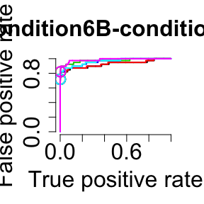

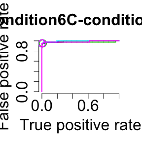

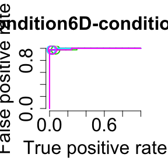

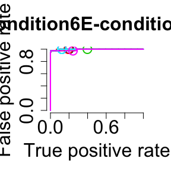

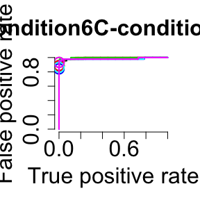

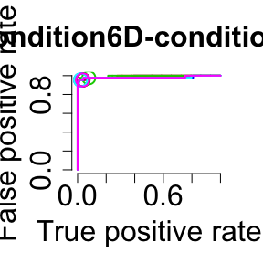

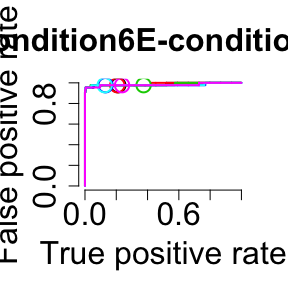

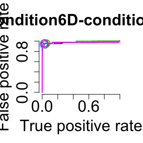

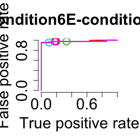

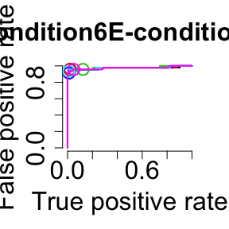

```
## $AUC
##                              [,1]      [,2]      [,3]      [,4]      [,5]
## condition6B-condition6A 0.9239222 0.9255424 0.9715589 0.9612919 0.9624542
## condition6C-condition6A 0.9895704 0.9907045 0.9731271 0.9941409 0.9948282
## condition6D-condition6A 0.9956044 0.9961882 0.9897493 0.9979224 0.9982658
## condition6E-condition6A 0.9957557 0.9962905 0.9913043 0.9975155 0.9979296
## condition6C-condition6B 0.9904158 0.9928509 0.9952391 0.9812531 0.9815497
## condition6D-condition6B 0.9871379 0.9901349 0.9926480 0.9802853 0.9807380
## condition6E-condition6B 0.9847333 0.9872620 0.9839323 0.9811522 0.9816234
## condition6D-condition6C 0.9746642 0.9769994 0.9839133 0.9730464 0.9735653
## condition6E-condition6C 0.9794671 0.9814943 0.9767642 0.9782078 0.9789757
## condition6E-condition6D 0.9711441 0.9725943 0.9763471 0.9757341 0.9766013
##                              [,6]
## condition6B-condition6A 0.9851367
## condition6C-condition6A 0.9841409
## condition6D-condition6A 0.9939732
## condition6E-condition6A 0.9929607
## condition6C-condition6B 0.9827672
## condition6D-condition6B 0.9818619
## condition6E-condition6B 0.9811208
## condition6D-condition6C 0.9747405
## condition6E-condition6C 0.9781924
## condition6E-condition6D 0.9751809
##
## $pAUC
##                               [,1]       [,2]       [,3]       [,4]
## condition6B-condition6A 0.08252325 0.08310440 0.09002536 0.08475979
## condition6C-condition6A 0.09580756 0.09616838 0.09625430 0.09659794
## condition6D-condition6A 0.09725275 0.09783654 0.09708104 0.09751030
## condition6E-condition6A 0.09720497 0.09773982 0.09680814 0.09689441
## condition6C-condition6B 0.09496753 0.09563874 0.09710602 0.09640360
## condition6D-condition6B 0.09543581 0.09581044 0.09688749 0.09598214
## condition6E-condition6B 0.09584092 0.09618647 0.09632783 0.09588804
## condition6D-condition6C 0.09336081 0.09365079 0.09455128 0.09368132
## condition6E-condition6C 0.09501651 0.09503187 0.09506258 0.09501651
## condition6E-condition6D 0.09435739 0.09474613 0.09507506 0.09468632
##                               [,5]       [,6]
## condition6B-condition6A 0.08505917 0.09131093
## condition6C-condition6A 0.09676976 0.09673540
## condition6D-condition6A 0.09785371 0.09708104
## condition6E-condition6A 0.09730849 0.09680814
## condition6C-condition6B 0.09659091 0.09665335
## condition6D-condition6B 0.09615385 0.09630994
## condition6E-condition6B 0.09623359 0.09494566
## condition6D-condition6C 0.09386447 0.09467338
## condition6E-condition6C 0.09500115 0.09500115
## condition6E-condition6D 0.09486574 0.09443215
```

```r
colors <- c(1,2,3,4,5,6)
resultobjectlist <- list(lm_normal,lm_Sq,lm_SqM,ridge,ridgeSq,ridgeSqM)

truth <- lm_normal[[1]][,"ups"]
names(truth) <- rownames(lm_normal[[1]])
summary_objectlist <- lapply(resultobjectlist, function(x){return(makeSummary(x, upratio))})

plotROC(resultobjectlist, summary_objectlist=summary_objectlist, proteins=proteinsCPTAC, truth=truth, colors=colors, plotSVG=FALSE)
```

## References

Argentini, A., Goeminne, L. J. E., Verheggen, K., Hulstaert, N., Staes, A., Clement, L. and Martens, L. (2016) moFF: a robust and automated approach to extract peptide ion intensities. Nature Methods 13, pp 964–966.

Bolstad, B. M., Irizarry, R. A., Astrand, M., and Speed, T. P. (2003) A Comparison of Normalization Methods for High Density Oligonucleotide Array Data Based on Bias and Variance. Bioinformatics 19(2), pp 185-193. http://bmbolstad.com/misc/normalize/normalize.html

Goeminne, L. J. E., Argentini, A., Martens, L., and Clement, L. (2015) Summarization vs Peptide-Based Models in Label-Free Quantitative Proteomics: Performance, Pitfalls, and Data Analysis Guidelines. Journal of Proteome Research 14(6), pp 2457-2465.

Goeminne, L. J. E., Gevaert, K., and Clement, L. (2016) Peptide-level Robust Ridge Regression Improves Estimation, Sensitivity, and Specificity in Data-dependent Quantitative Label-free Shotgun Proteomics. Molecular & Cellular Proteomics 15(2), pp 657-668.

Griss, J., Jones, A.R., Sachsenberg, T., Walzer, M., Gatto, L., Hartler, J., Thallinger, G.G., Salek, R.M., Steinbeck, C., Neuhauser, N., Cox, J., Neumann, S., Fan, J., Reisinger, F., Xu, Q.W., Del Toro, N., Pérez-Riverol, Y., Ghali, F., Bandeira, N., Xenarios, I., Kohlbacher, O., Vizcaíno, J.A. & Hermjakob, H. (2014) The mzTab data exchange format: communicating mass-spectrometry-based proteomics and metabolomics experimental results to a wider audience. Molecular and Cellular Proteomics 13(10), pp 2765-75.

Navarro P., Kuharev J., Gillet, L. C., Bernhardt, O. M., MacLean, B., Röst, H. L., Tate, S. A., Tsou, C., Reiter, L., Distler, U., Rosenberger, G., Perez-Riverol, Y., Nesvizhskii, A. I., Aebersold, R., and Tenzer, S. (2016) A multicenter study benchmarks software tools for label-free proteome quantification. Nature Biotechnology.

Paulovich AG, Billheimer D, Ham A-JL, et al. (2010) Interlaboratory Study Characterizing a Yeast Performance Standard for Benchmarking LC-MS Platform Performance. Molecular & Cellular Proteomic 9(2), pp 242-254.

Ramond, E., Gesbert, G., Guerrera, I. C., Chhuon, C., Dupuis, M., Rigard, M., Henry, T., Barel, M., and Charbit, A. (2015) Importance of host cell arginine uptake in Francisella phagosomal escape and ribosomal protein amounts. Molecular & Cellular Proteomics 14, pp 870–881.